# Histogram_per_cluster_MSR1_v_WNT2

Alvaro Regano

9/29/2021

# 1 About the analysis

The data was taken from the Liver 20-01-21 sample processed by Carlos Torroja. In brief, we want to find out if there is a unbalance in the arterio-venous differentiation of LOF cells in the 3 conditions (Dll4LOF, RbpjLOF and Notch1LOF). For that we have selected 2 markers, MSR1 and WNT2, the former a validated arterial marker and the latter a venous one.

This analysis follows the one performed with the previous Histogram of MSR1vWNT2. Now we want to pinpoint where in the different clusters do these cells localize, and what % of each condition belongs to each cluster.

Same criteria will be followed for the gene range between MSR1 and WNT2

no expression = MSR1 and WNT2<=0

MSR1lo-noWNT2 = 0<MSR1<=2 and WNT2<=0

MSR1hi-noWNT2 = MSR1>2 and WNT2<=0

noMSR1-WNT2lo = MSR1<=0 and 0<WNT2<=2

MSR1lo-WNT2lo = 0<MSR1<=2 and 0<WNT2<=2

MSR1hi-WNT2lo = MSR1>2 and 0<WNT2<=2

MSR1lo-WNT2hi = 0<MSR1<=2 and WNT2>2

MSR1hi-WNT2hi = MSR1>2 and WNT2>2

# 2 Objective

The goal is to find how the different rates of MSR1vWNT2 cells localize around the different set of clusters previously stablished, so as to find key statistical differences in the cell transcriptomes producing the arteriovenous differentiation in the Liver dataset.

```r
library("Seurat")
library("ggplot2")
library("RColorBrewer")
library("openxlsx")
```

## 2.1 Analysis

```r
  Carlos <- readRDS("SC.Analysis.SecondPass.RNA.Singlets.Endothelial.ManualClustering.seuratSC.Final.V4.rds")
  Control <- subset(x = Carlos, subset = Condition == "Control")
  Dll4KO <- subset(x = Carlos, subset = Condition == "Dll4KO")
  RbpjKO <- subset(x = Carlos, subset = Condition == "RBPJKO")
  Notch1KO <- subset(x = Carlos, subset = Condition == "NOTCH1KO")

  my_palette <- c(brewer.pal(10, "Paired"))
```

```r
  lo_lo <- subset(Control, subset = MSR1 <= 0 & WNT2 <= 0)
  med_lo <- subset(Control, subset = MSR1 > 0 & MSR1 <= 2 & WNT2 <= 0)
  hi_lo <- subset(Control, subset = MSR1 > 2 & WNT2 <= 0)

  lo_med <- subset(Control, subset = MSR1 <= 0 & WNT2 > 0 & WNT2 <= 2)
  med_med <- subset(Control, subset = MSR1 > 0 & MSR1 <= 2 & WNT2 > 0 & WNT2 <= 2)
  hi_med <- subset(Control, subset = MSR1 > 2 & WNT2 > 0 & WNT2 <= 2)

  lo_hi <- subset(Control, subset = MSR1 <= 0 & WNT2 > 0)
  med_hi <- subset(Control, subset = MSR1 > 0 & MSR1 <= 2 & WNT2 > 2)
  hi_hi <- subset(Control, subset = MSR1 > 2 & WNT2 > 2)
```

```r
  lo_lo_C0a <- subset(lo_lo, idents = "C0a")
  lo_lo_C0v <- subset(lo_lo, idents = "C0v")
  lo_lo_C1 <- subset(lo_lo, idents = "C1")
  lo_lo_C2 <- subset(lo_lo, idents = "C2")
  #lo_lo_C3 <- subset(lo_lo, idents = "C3")
  lo_lo_C3 <- 0
  lo_lo_C4ip <- subset(lo_lo, idents = "C4ip")
  lo_lo_C4p <- subset(lo_lo, idents = "C4p")
  lo_lo_C5 <- subset(lo_lo, idents = "C5")
  lo_lo_C6a <- subset(lo_lo, idents = "C6a")
  #lo_lo_C6v <- subset(lo_lo, idents = "C6v")
  lo_lo_C6v <- 0

  med_lo_C0a <- subset(med_lo, idents = "C0a")
  med_lo_C0v <- subset(med_lo, idents = "C0v")
  med_lo_C1 <- subset(med_lo, idents = "C1")
  med_lo_C2 <- subset(med_lo, idents = "C2")
  # med_lo_C3 <- subset(med_lo, idents = "C3")
  med_lo_C3 <- 0
  med_lo_C4ip <- subset(med_lo, idents = "C4ip")
  med_lo_C4p <- subset(med_lo, idents = "C4p")
  med_lo_C5 <- subset(med_lo, idents = "C5")
  med_lo_C6a <- subset(med_lo, idents = "C6a")
  # med_lo_C6v <- subset(med_lo, idents = "C6v")
  med_lo_C6v <- 0

  hi_lo_C0a <- subset(hi_lo, idents = "C0a")
  hi_lo_C0v <- subset(hi_lo, idents = "C0v")
  #hi_lo_C1 <- subset(hi_lo, idents = "C1")
  hi_lo_C1 <- 0
  hi_lo_C2 <- subset(hi_lo, idents = "C2")
  #hi_lo_C3 <- subset(hi_lo, idents = "C3")
  hi_lo_C3 <- 0
  hi_lo_C4ip <- subset(hi_lo, idents = "C4ip")
  #hi_lo_C4p <- subset(hi_lo, idents = "C4p")
  hi_lo_C4p <- 0
  hi_lo_C5 <- subset(hi_lo, idents = "C5")
  hi_lo_C6a <- subset(hi_lo, idents = "C6a")
  #hi_lo_C6v <- subset(hi_lo, idents = "C6v")
  hi_lo_C6v <- 0

  lo_med_C0a <- subset(lo_med, idents = "C0a")
  lo_med_C0v <- subset(lo_med, idents = "C0v")
  lo_med_C1 <- subset(lo_med, idents = "C1")
  lo_med_C2 <- subset(lo_med, idents = "C2")
  #lo_med_C3 <- subset(lo_med, idents = "C3")
  lo_med_C3 <- 0
  lo_med_C4ip <- subset(lo_med, idents = "C4ip")
  lo_med_C4p <- subset(lo_med, idents = "C4p")
  lo_med_C5 <- subset(lo_med, idents = "C5")
  lo_med_C6a <- subset(lo_med, idents = "C6a")
  lo_med_C6v <- subset(lo_med, idents = "C6v")

  med_med_C0a <- subset(med_med, idents = "C0a")
  med_med_C0v <- subset(med_med, idents = "C0v")
  med_med_C1 <- subset(med_med, idents = "C1")
  med_med_C2 <- subset(med_med, idents = "C2")
  #med_med_C3 <- subset(med_med, idents = "C3")
  med_med_C3 <- 0
  med_med_C4ip <- subset(med_med, idents = "C4ip")
  med_med_C4p <- subset(med_med, idents = "C4p")
  #med_med_C5 <- subset(med_med, idents = "C5")
  med_med_C5 <- 0
  med_med_C6a <- subset(med_med, idents = "C6a")
  med_med_C6v <- subset(med_med, idents = "C6v")

  hi_med_C0a <- subset(hi_med, idents = "C0a")
  hi_med_C0v <- subset(hi_med, idents = "C0v")
  hi_med_C1 <- subset(hi_med, idents = "C1")
  hi_med_C2 <- subset(hi_med, idents = "C2")
  # hi_med_C3 <- subset(hi_med, idents = "C3")
  hi_med_C3 <- 0
  hi_med_C4ip <- subset(hi_med, idents = "C4ip")
  #hi_med_C4p <- subset(hi_med, idents = "C4p")
  hi_med_C4p <- 0
  #hi_med_C5 <- subset(hi_med, idents = "C5")
  hi_med_C5 <- 0
  hi_med_C6a <- subset(hi_med, idents = "C6a")
  # hi_med_C6v <- subset(hi_med, idents = "C6v")
  hi_med_C6v <- 0

  lo_hi_C0a <- subset(lo_hi, idents = "C0a")
  lo_hi_C0v <- subset(lo_hi, idents = "C0v")
  lo_hi_C1 <- subset(lo_hi, idents = "C1")
  lo_hi_C2 <- subset(lo_hi, idents = "C2")
  #lo_hi_C3 <- subset(lo_hi, idents = "C3")
  lo_hi_C3 <- 0
  lo_hi_C4ip <- subset(lo_hi, idents = "C4ip")
  lo_hi_C4p <- subset(lo_hi, idents = "C4p")
  lo_hi_C5 <- subset(lo_hi, idents = "C5")
  lo_hi_C6a <- subset(lo_hi, idents = "C6a")
  lo_hi_C6v <- subset(lo_hi, idents = "C6v")

  med_hi_C0a <- subset(med_hi, idents = "C0a")
  med_hi_C0v <- subset(med_hi, idents = "C0v")
  #med_hi_C1 <- subset(med_hi, idents = "C1")
  med_hi_C1 <- 0
  med_hi_C2 <- subset(med_hi, idents = "C2")
  #med_hi_C3 <- subset(med_hi, idents = "C3")
  med_hi_C3 <- 0
  # med_hi_C4ip <- subset(med_hi, idents = "C4ip")
  med_hi_C4ip <- 0
  # med_hi_C4p <- subset(med_hi, idents = "C4p")
  med_hi_C4p <- 0
  # med_hi_C5 <- subset(med_hi, idents = "C5")
  med_hi_C5 <- 0
  # med_hi_C6a <- subset(med_hi, idents = "C6a")
  med_hi_C6a <- 0
  med_hi_C6v <- subset(med_hi, idents = "C6v")

  hi_hi_C0a <- subset(hi_hi, idents = "C0a")
  # hi_hi_C0v <- subset(hi_hi, idents = "C0v")
  hi_hi_C0v <- 0
  # hi_hi_C1 <- subset(hi_hi, idents = "C1")
  hi_hi_C1 <- 0
  hi_hi_C2 <- subset(hi_hi, idents = "C2")
  #hi_hi_C3 <- subset(hi_hi, idents = "C3")
  hi_hi_C3 <- 0
  # hi_hi_C4ip <- subset(hi_hi, idents = "C4ip")
  hi_hi_C4ip <- 0
  # hi_hi_C4p <- subset(hi_hi, idents = "C4p")
  hi_hi_C4p <- 0
  # hi_hi_C5 <- subset(hi_hi, idents = "C5")
  hi_hi_C5 <- 0
  # hi_hi_C6a <- subset(hi_hi, idents = "C6a")
  hi_hi_C6a <- 0
  # hi_hi_C6v <- subset(hi_hi, idents = "C6v")
  hi_hi_C6v <- 0

  lo_lo_h1 <- ncol(lo_lo_C0a)
  lo_lo_h2 <- ncol(lo_lo_C0v)
  lo_lo_h3 <- ncol(lo_lo_C1)
  lo_lo_h4 <- ncol(lo_lo_C2)
  lo_lo_h5 <- ncol(lo_lo_C3)
  lo_lo_h6 <- ncol(lo_lo_C4ip)
  lo_lo_h7 <- ncol(lo_lo_C4p)
  lo_lo_h8 <- ncol(lo_lo_C5)
  lo_lo_h9 <- ncol(lo_lo_C6a)
  lo_lo_h10 <- ncol(lo_lo_C6v)

  med_lo_h1 <- ncol(med_lo_C0a)
  med_lo_h2 <- ncol(med_lo_C0v)
  med_lo_h3 <- ncol(med_lo_C1)
  med_lo_h4 <- ncol(med_lo_C2)
  med_lo_h5 <- ncol(med_lo_C3)
  med_lo_h6 <- ncol(med_lo_C4ip)
  med_lo_h7 <- ncol(med_lo_C4p)
  med_lo_h8 <- ncol(med_lo_C5)
  med_lo_h9 <- ncol(med_lo_C6a)
  med_lo_h10 <- ncol(med_lo_C6v)

  hi_lo_h1 <- ncol(hi_lo_C0a)
  hi_lo_h2 <- ncol(hi_lo_C0v)
  hi_lo_h3 <- ncol(hi_lo_C1)
  hi_lo_h4 <- ncol(hi_lo_C2)
  hi_lo_h5 <- ncol(hi_lo_C3)
  hi_lo_h6 <- ncol(hi_lo_C4ip)
  hi_lo_h7 <- ncol(hi_lo_C4p)
  hi_lo_h8 <- ncol(hi_lo_C5)
  hi_lo_h9 <- ncol(hi_lo_C6a)
  hi_lo_h10 <- ncol(hi_lo_C6v)

  lo_med_h1 <- ncol(lo_med_C0a)
  lo_med_h2 <- ncol(lo_med_C0v)
  lo_med_h3 <- ncol(lo_med_C1)
  lo_med_h4 <- ncol(lo_med_C2)
  lo_med_h5 <- ncol(lo_med_C3)
  lo_med_h6 <- ncol(lo_med_C4ip)
  lo_med_h7 <- ncol(lo_med_C4p)
  lo_med_h8 <- ncol(lo_med_C5)
  lo_med_h9 <- ncol(lo_med_C6a)
  lo_med_h10 <- ncol(lo_med_C6v)

  med_med_h1 <- ncol(med_med_C0a)
  med_med_h2 <- ncol(med_med_C0v)
  med_med_h3 <- ncol(med_med_C1)
  med_med_h4 <- ncol(med_med_C2)
  med_med_h5 <- ncol(med_med_C3)
  med_med_h6 <- ncol(med_med_C4ip)
  med_med_h7 <- ncol(med_med_C4p)
  med_med_h8 <- ncol(med_med_C5)
  med_med_h9 <- ncol(med_med_C6a)
  med_med_h10 <- ncol(med_med_C6v)

  hi_med_h1 <- ncol(hi_med_C0a)
  hi_med_h2 <- ncol(hi_med_C0v)
  hi_med_h3 <- ncol(hi_med_C1)
  hi_med_h4 <- ncol(hi_med_C2)
  hi_med_h5 <- ncol(hi_med_C3)
  hi_med_h6 <- ncol(hi_med_C4ip)
  hi_med_h7 <- ncol(hi_med_C4p)
  hi_med_h8 <- ncol(hi_med_C5)
  hi_med_h9 <- ncol(hi_med_C6a)
  hi_med_h10 <- ncol(hi_med_C6v)

  lo_hi_h1 <- ncol(lo_hi_C0a)
  lo_hi_h2 <- ncol(lo_hi_C0v)
  lo_hi_h3 <- ncol(lo_hi_C1)
  lo_hi_h4 <- ncol(lo_hi_C2)
  lo_hi_h5 <- ncol(lo_hi_C3)
  lo_hi_h6 <- ncol(lo_hi_C4ip)
  lo_hi_h7 <- ncol(lo_hi_C4p)
  lo_hi_h8 <- ncol(lo_hi_C5)
  lo_hi_h9 <- ncol(lo_hi_C6a)
  lo_hi_h10 <- ncol(lo_hi_C6v)

  med_hi_h1 <- ncol(med_hi_C0a)
  med_hi_h2 <- ncol(med_hi_C0v)
  med_hi_h3 <- ncol(med_hi_C1)
  med_hi_h4 <- ncol(med_hi_C2)
  med_hi_h5 <- ncol(med_hi_C3)
  med_hi_h6 <- ncol(med_hi_C4ip)
  med_hi_h7 <- ncol(med_hi_C4p)
  med_hi_h8 <- ncol(med_hi_C5)
  med_hi_h9 <- ncol(med_hi_C6a)
  med_hi_h10 <- ncol(med_hi_C6v)

  hi_hi_h1 <- ncol(hi_hi_C0a)
  hi_hi_h2 <- ncol(hi_hi_C0v)
  hi_hi_h3 <- ncol(hi_hi_C1)
  hi_hi_h4 <- ncol(hi_hi_C2)
  hi_hi_h5 <- ncol(hi_hi_C3)
  hi_hi_h6 <- ncol(hi_hi_C4ip)
  hi_hi_h7 <- ncol(hi_hi_C4p)
  hi_hi_h8 <- ncol(hi_hi_C5)
  hi_hi_h9 <- ncol(hi_hi_C6a)
  hi_hi_h10 <- ncol(hi_hi_C6v)

  ncell_list_per_cluster_Control <- matrix(c( lo_lo_h1, lo_lo_h2, lo_lo_h3, lo_lo_h4, 0, lo_lo_h6, lo_lo_h7, lo_lo_h8, lo_lo_h9, 0,  hi_lo_h1, hi_lo_h2, 0, hi_lo_h4, 0, hi_lo_h6, 0, hi_lo_h8, hi_lo_h9, 0,  med_lo_h1, med_lo_h2, med_lo_h3, med_lo_h4, 0, med_lo_h6, med_lo_h7, med_lo_h8, med_lo_h9, 0,  hi_med_h1, hi_med_h2, hi_med_h3, hi_med_h4, 0, hi_med_h6, 0, 0, hi_med_h9, 0,  med_med_h1, med_med_h2, med_med_h3, med_med_h4, 0, med_med_h6, med_med_h7, 0, med_med_h9, med_med_h10,  hi_hi_h1, 0, 0, hi_hi_h4, 0, 0, 0, 0, 0, 0,  med_hi_h1, med_hi_h2, 0, med_hi_h4, 0, 0, 0, 0, 0, med_hi_h10, lo_med_h1, lo_med_h2, lo_med_h3, lo_med_h4, 0, lo_med_h6, lo_med_h7, lo_med_h8, lo_med_h9, lo_med_h10,  lo_hi_h1, lo_hi_h2, lo_hi_h3, lo_hi_h4, 0, lo_hi_h6, lo_hi_h7, lo_hi_h8, lo_hi_h9, lo_hi_h10), ncol = 9, nrow = 10,
  dimnames = list(c("C0a", "C0v", "C1", "C2", "C3", "C4ip", "C4p", "C5", "C6a", "C6v"),
                                               c("no expr", "MSR1hi-noWNT2", "MSR1lo-noWNT2", "MSR1hi-WNT2lo", "MSR1lo-WNT2lo", "MSR1hi-WNT2hi", "MSR1lo-WNT2hi", "noMSR1-WNT2lo", "noMSR1-WNT2hi")))

  ncell_list_per_cluster_Control
```

```
##      no expr MSR1hi-noWNT2 MSR1lo-noWNT2 MSR1hi-WNT2lo MSR1lo-WNT2lo
## C0a       30           101            75            50            36
## C0v       19             8            13             8            21
## C1        11             0             2             1             4
## C2        58            55            23             8             4
## C3         0             0             0             0             0
## C4ip       6             3             2             2             2
## C4p        2             0             2             0             1
## C5        23            10             8             0             0
## C6a        6            26            16             1             1
## C6v        0             0             0             0             1
##      MSR1hi-WNT2hi MSR1lo-WNT2hi noMSR1-WNT2lo noMSR1-WNT2hi
## C0a              1             2            17            21
## C0v              0             2            70           115
## C1               0             0            11            11
## C2               2             1            26            39
## C3               0             0             0             0
## C4ip             0             0             8             8
## C4p              0             0             2             2
## C5               0             0            14            18
## C6a              0             0             1             1
## C6v              0             1            16            41
```

```r
  lo_lo <- subset(Dll4KO, subset = MSR1 <= 0 & WNT2 <= 0)
  med_lo <- subset(Dll4KO, subset = MSR1 > 0 & MSR1 <= 2 & WNT2 <= 0)
  # hi_lo <- subset(Dll4KO, subset = MSR1 > 2 & WNT2 <= 0)
  hi_lo <- 0

  lo_med <- subset(Dll4KO, subset = MSR1 <= 0 & WNT2 > 0 & WNT2 <= 2)
  med_med <- subset(Dll4KO, subset = MSR1 > 0 & MSR1 <= 2 & WNT2 > 0 & WNT2 <= 2)
  # hi_med <- subset(Dll4KO, subset = MSR1 > 2 & WNT2 > 0 & WNT2 <= 2)
  hi_med <- 0

  lo_hi <- subset(Dll4KO, subset = MSR1 <= 0 & WNT2 > 0)
  med_hi <- subset(Dll4KO, subset = MSR1 > 0 & MSR1 <= 2 & WNT2 > 2)
  # hi_hi <- subset(Dll4KO, subset = MSR1 > 2 & WNT2 > 2)
  hi_hi <- 0
```

```r
  lo_lo_C0a <- subset(lo_lo, idents = "C0a")
  lo_lo_C0v <- subset(lo_lo, idents = "C0v")
  lo_lo_C1 <- subset(lo_lo, idents = "C1")
  lo_lo_C2 <- subset(lo_lo, idents = "C2")
  lo_lo_C3 <- subset(lo_lo, idents = "C3")
  lo_lo_C4ip <- subset(lo_lo, idents = "C4ip")
  lo_lo_C4p <- subset(lo_lo, idents = "C4p")
  lo_lo_C5 <- subset(lo_lo, idents = "C5")
  lo_lo_C6a <- subset(lo_lo, idents = "C6a")
  # lo_lo_C6v <- subset(lo_lo, idents = "C6v")
  lo_lo_C6v <- 0

  # med_lo_C0a <- subset(med_lo, idents = "C0a")
  med_lo_C0a <- 0
  med_lo_C0v <- subset(med_lo, idents = "C0v")
  med_lo_C1 <- subset(med_lo, idents = "C1")
  # med_lo_C2 <- subset(med_lo, idents = "C2")
  med_lo_C2 <- 0
  med_lo_C3 <- subset(med_lo, idents = "C3")
  med_lo_C4ip <- subset(med_lo, idents = "C4ip")
  med_lo_C4p <- subset(med_lo, idents = "C4p")
  med_lo_C5 <- subset(med_lo, idents = "C5")
  med_lo_C6a <- subset(med_lo, idents = "C6a")
  # med_lo_C6v <- subset(med_lo, idents = "C6v")
  med_lo_C6v <- 0

  # hi_lo_C0a <- subset(hi_lo, idents = "C0a")
  # hi_lo_C0v <- subset(hi_lo, idents = "C0v")
  # hi_lo_C1 <- subset(hi_lo, idents = "C1")
  # hi_lo_C2 <- subset(hi_lo, idents = "C2")
  # hi_lo_C3 <- subset(hi_lo, idents = "C3")
  # hi_lo_C4ip <- subset(hi_lo, idents = "C4ip")
  # hi_lo_C4p <- subset(hi_lo, idents = "C4p")
  # hi_lo_C5 <- subset(hi_lo, idents = "C5")
  # hi_lo_C6a <- subset(hi_lo, idents = "C6a")
  # hi_lo_C6v <- subset(hi_lo, idents = "C6v")

  lo_med_C0a <- subset(lo_med, idents = "C0a")
  lo_med_C0v <- subset(lo_med, idents = "C0v")
  lo_med_C1 <- subset(lo_med, idents = "C1")
  lo_med_C2 <- subset(lo_med, idents = "C2")
  lo_med_C3 <- subset(lo_med, idents = "C3")
  lo_med_C4ip <- subset(lo_med, idents = "C4ip")
  lo_med_C4p <- subset(lo_med, idents = "C4p")
  lo_med_C5 <- subset(lo_med, idents = "C5")
  lo_med_C6a <- subset(lo_med, idents = "C6a")
  lo_med_C6v <- subset(lo_med, idents = "C6v")

  med_med_C0a <- subset(med_med, idents = "C0a")
  med_med_C0v <- subset(med_med, idents = "C0v")
  med_med_C1 <- subset(med_med, idents = "C1")
  med_med_C2 <- subset(med_med, idents = "C2")
  med_med_C3 <- subset(med_med, idents = "C3")
  med_med_C4ip <- subset(med_med, idents = "C4ip")
  med_med_C4p <- subset(med_med, idents = "C4p")
  # med_med_C5 <- subset(med_med, idents = "C5")
  med_med_C5 <- 0
  med_med_C6a <- subset(med_med, idents = "C6a")
  # med_med_C6v <- subset(med_med, idents = "C6v")
  med_med_C6v <- 0

  # hi_med_C0a <- subset(hi_med, idents = "C0a")
  # hi_med_C0v <- subset(hi_med, idents = "C0v")
  # hi_med_C1 <- subset(hi_med, idents = "C1")
  # hi_med_C2 <- subset(hi_med, idents = "C2")
  # hi_med_C3 <- subset(hi_med, idents = "C3")
  # hi_med_C4ip <- subset(hi_med, idents = "C4ip")
  # hi_med_C4p <- subset(hi_med, idents = "C4p")
  # hi_med_C5 <- subset(hi_med, idents = "C5")
  # hi_med_C6a <- subset(hi_med, idents = "C6a")
  # hi_med_C6v <- subset(hi_med, idents = "C6v")

  lo_hi_C0a <- subset(lo_hi, idents = "C0a")
  lo_hi_C0v <- subset(lo_hi, idents = "C0v")
  lo_hi_C1 <- subset(lo_hi, idents = "C1")
  lo_hi_C2 <- subset(lo_hi, idents = "C2")
  lo_hi_C3 <- subset(lo_hi, idents = "C3")
  lo_hi_C4ip <- subset(lo_hi, idents = "C4ip")
  lo_hi_C4p <- subset(lo_hi, idents = "C4p")
  lo_hi_C5 <- subset(lo_hi, idents = "C5")
  lo_hi_C6a <- subset(lo_hi, idents = "C6a")
  lo_hi_C6v <- subset(lo_hi, idents = "C6v")

  # med_hi_C0a <- subset(med_hi, idents = "C0a")
  med_hi_C0a <- 0
  # med_hi_C0v <- subset(med_hi, idents = "C0v")
  med_hi_C0v <-0
  med_hi_C1 <- subset(med_hi, idents = "C1")
  # med_hi_C2 <- subset(med_hi, idents = "C2")
  med_hi_C2 <- 0
  # med_hi_C3 <- subset(med_hi, idents = "C3")
  med_hi_C3 <- 0
  # med_hi_C4ip <- subset(med_hi, idents = "C4ip")
  med_hi_C4ip <- 0
  # med_hi_C4p <- subset(med_hi, idents = "C4p")
  med_hi_C4p <- 0
  # med_hi_C5 <- subset(med_hi, idents = "C5")
  med_hi_C5 <- 0
  # med_hi_C6a <- subset(med_hi, idents = "C6a")
  med_hi_C6a <- 0
  # med_hi_C6v <- subset(med_hi, idents = "C6v")
  med_hi_C6v <- 0

  # hi_hi_C0a <- subset(hi_hi, idents = "C0a")
  # hi_hi_C0v <- subset(hi_hi, idents = "C0v")
  # hi_hi_C1 <- subset(hi_hi, idents = "C1")
  # hi_hi_C2 <- subset(hi_hi, idents = "C2")
  # hi_hi_C3 <- subset(hi_hi, idents = "C3")
  # hi_hi_C4ip <- subset(hi_hi, idents = "C4ip")
  # hi_hi_C4p <- subset(hi_hi, idents = "C4p")
  # hi_hi_C5 <- subset(hi_hi, idents = "C5")
  # hi_hi_C6a <- subset(hi_hi, idents = "C6a")
  # hi_hi_C6v <- subset(hi_hi, idents = "C6v")

  lo_lo_h1 <- ncol(lo_lo_C0a)
  lo_lo_h2 <- ncol(lo_lo_C0v)
  lo_lo_h3 <- ncol(lo_lo_C1)
  lo_lo_h4 <- ncol(lo_lo_C2)
  lo_lo_h5 <- ncol(lo_lo_C3)
  lo_lo_h6 <- ncol(lo_lo_C4ip)
  lo_lo_h7 <- ncol(lo_lo_C4p)
  lo_lo_h8 <- ncol(lo_lo_C5)
  lo_lo_h9 <- ncol(lo_lo_C6a)
  lo_lo_h10 <- ncol(lo_lo_C6v)

  med_lo_h1 <- ncol(med_lo_C0a)
  med_lo_h2 <- ncol(med_lo_C0v)
  med_lo_h3 <- ncol(med_lo_C1)
  med_lo_h4 <- ncol(med_lo_C2)
  med_lo_h5 <- ncol(med_lo_C3)
  med_lo_h6 <- ncol(med_lo_C4ip)
  med_lo_h7 <- ncol(med_lo_C4p)
  med_lo_h8 <- ncol(med_lo_C5)
  med_lo_h9 <- ncol(med_lo_C6a)
  med_lo_h10 <- ncol(med_lo_C6v)

  # hi_lo_h1 <- ncol(hi_lo_C0a)
  # hi_lo_h2 <- ncol(hi_lo_C0v)
  # hi_lo_h3 <- ncol(hi_lo_C1)
  # hi_lo_h4 <- ncol(hi_lo_C2)
  # hi_lo_h5 <- ncol(hi_lo_C3)
  # hi_lo_h6 <- ncol(hi_lo_C4ip)
  # hi_lo_h7 <- ncol(hi_lo_C4p)
  # hi_lo_h8 <- ncol(hi_lo_C5)
  # hi_lo_h9 <- ncol(hi_lo_C6a)
  # hi_lo_h10 <- ncol(hi_lo_C6v)

  lo_med_h1 <- ncol(lo_med_C0a)
  lo_med_h2 <- ncol(lo_med_C0v)
  lo_med_h3 <- ncol(lo_med_C1)
  lo_med_h4 <- ncol(lo_med_C2)
  lo_med_h5 <- ncol(lo_med_C3)
  lo_med_h6 <- ncol(lo_med_C4ip)
  lo_med_h7 <- ncol(lo_med_C4p)
  lo_med_h8 <- ncol(lo_med_C5)
  lo_med_h9 <- ncol(lo_med_C6a)
  lo_med_h10 <- ncol(lo_med_C6v)

  med_med_h1 <- ncol(med_med_C0a)
  med_med_h2 <- ncol(med_med_C0v)
  med_med_h3 <- ncol(med_med_C1)
  med_med_h4 <- ncol(med_med_C2)
  med_med_h5 <- ncol(med_med_C3)
  med_med_h6 <- ncol(med_med_C4ip)
  med_med_h7 <- ncol(med_med_C4p)
  med_med_h8 <- ncol(med_med_C5)
  med_med_h9 <- ncol(med_med_C6a)
  med_med_h10 <- ncol(med_med_C6v)

  # hi_med_h1 <- ncol(hi_med_C0a)
  # hi_med_h2 <- ncol(hi_med_C0v)
  # hi_med_h3 <- ncol(hi_med_C1)
  # hi_med_h4 <- ncol(hi_med_C2)
  # hi_med_h5 <- ncol(hi_med_C3)
  # hi_med_h6 <- ncol(hi_med_C4ip)
  # hi_med_h7 <- ncol(hi_med_C4p)
  # hi_med_h8 <- ncol(hi_med_C5)
  # hi_med_h9 <- ncol(hi_med_C6a)
  # hi_med_h10 <- ncol(hi_med_C6v)

  lo_hi_h1 <- ncol(lo_hi_C0a)
  lo_hi_h2 <- ncol(lo_hi_C0v)
  lo_hi_h3 <- ncol(lo_hi_C1)
  lo_hi_h4 <- ncol(lo_hi_C2)
  lo_hi_h5 <- ncol(lo_hi_C3)
  lo_hi_h6 <- ncol(lo_hi_C4ip)
  lo_hi_h7 <- ncol(lo_hi_C4p)
  lo_hi_h8 <- ncol(lo_hi_C5)
  lo_hi_h9 <- ncol(lo_hi_C6a)
  lo_hi_h10 <- ncol(lo_hi_C6v)

  med_hi_h1 <- ncol(med_hi_C0a)
  med_hi_h2 <- ncol(med_hi_C0v)
  med_hi_h3 <- ncol(med_hi_C1)
  med_hi_h4 <- ncol(med_hi_C2)
  med_hi_h5 <- ncol(med_hi_C3)
  med_hi_h6 <- ncol(med_hi_C4ip)
  med_hi_h7 <- ncol(med_hi_C4p)
  med_hi_h8 <- ncol(med_hi_C5)
  med_hi_h9 <- ncol(med_hi_C6a)
  med_hi_h10 <- ncol(med_hi_C6v)

  # hi_hi_h1 <- ncol(hi_hi_C0a)
  # hi_hi_h2 <- ncol(hi_hi_C0v)
  # hi_hi_h3 <- ncol(hi_hi_C1)
  # hi_hi_h4 <- ncol(hi_hi_C2)
  # hi_hi_h5 <- ncol(hi_hi_C3)
  # hi_hi_h6 <- ncol(hi_hi_C4ip)
  # hi_hi_h7 <- ncol(hi_hi_C4p)
  # hi_hi_h8 <- ncol(hi_hi_C5)
  # hi_hi_h9 <- ncol(hi_hi_C6a)
  # hi_hi_h10 <- ncol(hi_hi_C6v)

  ncell_list_per_cluster_Dll4KO <- matrix(c( lo_lo_h1, lo_lo_h2, lo_lo_h3, lo_lo_h4, lo_lo_h5, lo_lo_h6, lo_lo_h7, lo_lo_h8, lo_lo_h9, 0, 0, 0, 0, 0, 0, 0, 0, 0, 0, 0,  0, med_lo_h2, med_lo_h3, 0, med_lo_h5, med_lo_h6, med_lo_h7, med_lo_h8, med_lo_h9, 0,  0, 0, 0, 0, 0, 0, 0, 0, 0, 0,  med_med_h1, med_med_h2, med_med_h3, med_med_h4, med_med_h5, med_med_h6, med_med_h7, 0, med_med_h9, 0,  0, 0, 0, 0, 0, 0, 0, 0, 0, 0,  0, 0, med_hi_h3, 0, 0, 0, 0, 0, 0, 0, lo_med_h1, lo_med_h2, lo_med_h3, lo_med_h4, lo_med_h5, lo_med_h6, lo_med_h7, lo_med_h8, lo_med_h9, lo_med_h10,  lo_hi_h1, lo_hi_h2, lo_hi_h3, lo_hi_h4, lo_hi_h5, lo_hi_h6, lo_hi_h7, lo_hi_h8, lo_hi_h9, lo_hi_h10), ncol = 9, nrow = 10,
  dimnames = list(c("C0a", "C0v", "C1", "C2", "C3", "C4ip", "C4p", "C5", "C6a", "C6v"),
                                               c("no expr", "MSR1hi-noWNT2", "MSR1lo-noWNT2", "MSR1hi-WNT2lo", "MSR1lo-WNT2lo", "MSR1hi-WNT2hi", "MSR1lo-WNT2hi", "noMSR1-WNT2lo", "noMSR1-WNT2hi")))

  ncell_list_per_cluster_Dll4KO
```

```
##      no expr MSR1hi-noWNT2 MSR1lo-noWNT2 MSR1hi-WNT2lo MSR1lo-WNT2lo
## C0a        9             0             0             0             1
## C0v       22             0             2             0             5
## C1        73             0            23             0            62
## C2        13             0             0             0             1
## C3       250             0            50             0            17
## C4ip      30             0            16             0            17
## C4p       17             0             8             0             7
## C5         5             0             1             0             0
## C6a       10             0             3             0             2
## C6v        0             0             0             0             0
##      MSR1hi-WNT2hi MSR1lo-WNT2hi noMSR1-WNT2lo noMSR1-WNT2hi
## C0a              0             0             2             2
## C0v              0             0            24            33
## C1               0             4           123           145
## C2               0             0             5             5
## C3               0             0            31            32
## C4ip             0             0            27            28
## C4p              0             0            10            11
## C5               0             0             2             2
## C6a              0             0             9            10
## C6v              0             0             5             7
```

```r
  lo_lo <- subset(RbpjKO, subset = MSR1 <= 0 & WNT2 <= 0)
  med_lo <- subset(RbpjKO, subset = MSR1 > 0 & MSR1 <= 2 & WNT2 <= 0)
  hi_lo <- subset(RbpjKO, subset = MSR1 > 2 & WNT2 <= 0)

  lo_med <- subset(RbpjKO, subset = MSR1 <= 0 & WNT2 > 0 & WNT2 <= 2)
  med_med <- subset(RbpjKO, subset = MSR1 > 0 & MSR1 <= 2 & WNT2 > 0 & WNT2 <= 2)
  hi_med <- subset(RbpjKO, subset = MSR1 > 2 & WNT2 > 0 & WNT2 <= 2)

  lo_hi <- subset(RbpjKO, subset = MSR1 <= 0 & WNT2 > 0)
  med_hi <- subset(RbpjKO, subset = MSR1 > 0 & MSR1 <= 2 & WNT2 > 2)
  hi_hi <- subset(RbpjKO, subset = MSR1 > 2 & WNT2 > 2)
```

```r
  lo_lo_C0a <- subset(lo_lo, idents = "C0a")
  lo_lo_C0v <- subset(lo_lo, idents = "C0v")
  lo_lo_C1 <- subset(lo_lo, idents = "C1")
  lo_lo_C2 <- subset(lo_lo, idents = "C2")
  lo_lo_C3 <- subset(lo_lo, idents = "C3")
  lo_lo_C4ip <- subset(lo_lo, idents = "C4ip")
  lo_lo_C4p <- subset(lo_lo, idents = "C4p")
  lo_lo_C5 <- subset(lo_lo, idents = "C5")
  lo_lo_C6a <- subset(lo_lo, idents = "C6a")
  lo_lo_C6v <- subset(lo_lo, idents = "C6v")

  med_lo_C0a <- subset(med_lo, idents = "C0a")
  med_lo_C0v <- subset(med_lo, idents = "C0v")
  med_lo_C1 <- subset(med_lo, idents = "C1")
  med_lo_C2 <- subset(med_lo, idents = "C2")
  med_lo_C3 <- subset(med_lo, idents = "C3")
  med_lo_C4ip <- subset(med_lo, idents = "C4ip")
  med_lo_C4p <- subset(med_lo, idents = "C4p")
  med_lo_C5 <- subset(med_lo, idents = "C5")
  # med_lo_C6a <- subset(med_lo, idents = "C6a")
  med_lo_C6a <- 0
  # med_lo_C6v <- subset(med_lo, idents = "C6v")
  med_lo_C6v <- 0

  # hi_lo_C0a <- subset(hi_lo, idents = "C0a")
  hi_lo_C0a <- 0
  hi_lo_C0v <- subset(hi_lo, idents = "C0v")
  hi_lo_C1 <- subset(hi_lo, idents = "C1")
  hi_lo_C2 <- subset(hi_lo, idents = "C2")
  # hi_lo_C3 <- subset(hi_lo, idents = "C3")
  hi_lo_C3 <- 0
  hi_lo_C4ip <- subset(hi_lo, idents = "C4ip")
  hi_lo_C4p <- subset(hi_lo, idents = "C4p")
  hi_lo_C5 <- subset(hi_lo, idents = "C5")
  # hi_lo_C6a <- subset(hi_lo, idents = "C6a")
  hi_lo_C6a <- 0
  # hi_lo_C6v <- subset(hi_lo, idents = "C6v")
  hi_lo_C6v <- 0

  lo_med_C0a <- subset(lo_med, idents = "C0a")
  lo_med_C0v <- subset(lo_med, idents = "C0v")
  lo_med_C1 <- subset(lo_med, idents = "C1")
  lo_med_C2 <- subset(lo_med, idents = "C2")
  lo_med_C3 <- subset(lo_med, idents = "C3")
  lo_med_C4ip <- subset(lo_med, idents = "C4ip")
  lo_med_C4p <- subset(lo_med, idents = "C4p")
  lo_med_C5 <- subset(lo_med, idents = "C5")
  lo_med_C6a <- subset(lo_med, idents = "C6a")
  lo_med_C6v <- subset(lo_med, idents = "C6v")

  med_med_C0a <- subset(med_med, idents = "C0a")
  med_med_C0v <- subset(med_med, idents = "C0v")
  med_med_C1 <- subset(med_med, idents = "C1")
  med_med_C2 <- subset(med_med, idents = "C2")
  med_med_C3 <- subset(med_med, idents = "C3")
  med_med_C4ip <- subset(med_med, idents = "C4ip")
  med_med_C4p <- subset(med_med, idents = "C4p")
  med_med_C5 <- subset(med_med, idents = "C5")
  med_med_C6a <- subset(med_med, idents = "C6a")
  # med_med_C6v <- subset(med_med, idents = "C6v")
  med_med_C6v <- 0

  hi_med_C0a <- subset(hi_med, idents = "C0a")
  hi_med_C0v <- subset(hi_med, idents = "C0v")
  hi_med_C1 <- subset(hi_med, idents = "C1")
  hi_med_C2 <- subset(hi_med, idents = "C2")
  # hi_med_C3 <- subset(hi_med, idents = "C3")
  hi_med_C3 <- 0
  hi_med_C4ip <- subset(hi_med, idents = "C4ip")
  hi_med_C4p <- subset(hi_med, idents = "C4p")
  hi_med_C5 <- subset(hi_med, idents = "C5")
  # hi_med_C6a <- subset(hi_med, idents = "C6a")
  hi_med_C6a <- 0
  # hi_med_C6v <- subset(hi_med, idents = "C6v")
  hi_med_C6v <- 0

  lo_hi_C0a <- subset(lo_hi, idents = "C0a")
  lo_hi_C0v <- subset(lo_hi, idents = "C0v")
  lo_hi_C1 <- subset(lo_hi, idents = "C1")
  lo_hi_C2 <- subset(lo_hi, idents = "C2")
  lo_hi_C3 <- subset(lo_hi, idents = "C3")
  lo_hi_C4ip <- subset(lo_hi, idents = "C4ip")
  lo_hi_C4p <- subset(lo_hi, idents = "C4p")
  lo_hi_C5 <- subset(lo_hi, idents = "C5")
  lo_hi_C6a <- subset(lo_hi, idents = "C6a")
  lo_hi_C6v <- subset(lo_hi, idents = "C6v")

  med_hi_C0a <- subset(med_hi, idents = "C0a")
  med_hi_C0v <- subset(med_hi, idents = "C0v")
  med_hi_C1 <- subset(med_hi, idents = "C1")
  med_hi_C2 <- subset(med_hi, idents = "C2")
  # med_hi_C3 <- subset(med_hi, idents = "C3")
  med_hi_C3 <- 0
  med_hi_C4ip <- subset(med_hi, idents = "C4ip")
  # med_hi_C4p <- subset(med_hi, idents = "C4p")
  med_hi_C4p <- 0
  med_hi_C5 <- subset(med_hi, idents = "C5")
  # med_hi_C6a <- subset(med_hi, idents = "C6a")
  med_hi_C6a <- 0
  # med_hi_C6v <- subset(med_hi, idents = "C6v")
  med_hi_C6v <- 0

  # hi_hi_C0a <- subset(hi_hi, idents = "C0a")
  hi_hi_C0a <- 0
  # hi_hi_C0v <- subset(hi_hi, idents = "C0v")
  hi_hi_C0v <- 0
  # hi_hi_C1 <- subset(hi_hi, idents = "C1")
  hi_hi_C1 <- 0
  hi_hi_C2 <- subset(hi_hi, idents = "C2")
  # hi_hi_C3 <- subset(hi_hi, idents = "C3")
  hi_hi_C3 <- 0
  # hi_hi_C4ip <- subset(hi_hi, idents = "C4ip")
  hi_hi_C4ip <- 0
  # hi_hi_C4p <- subset(hi_hi, idents = "C4p")
  hi_hi_C4p <- 0
  # hi_hi_C5 <- subset(hi_hi, idents = "C5")
  hi_hi_C5 <- 0
  # hi_hi_C6a <- subset(hi_hi, idents = "C6a")
  hi_hi_C6a <- 0
  # hi_hi_C6v <- subset(hi_hi, idents = "C6v")
  hi_hi_C6v <- 0

  lo_lo_h1 <- ncol(lo_lo_C0a)
  lo_lo_h2 <- ncol(lo_lo_C0v)
  lo_lo_h3 <- ncol(lo_lo_C1)
  lo_lo_h4 <- ncol(lo_lo_C2)
  lo_lo_h5 <- ncol(lo_lo_C3)
  lo_lo_h6 <- ncol(lo_lo_C4ip)
  lo_lo_h7 <- ncol(lo_lo_C4p)
  lo_lo_h8 <- ncol(lo_lo_C5)
  lo_lo_h9 <- ncol(lo_lo_C6a)
  lo_lo_h10 <- ncol(lo_lo_C6v)

  med_lo_h1 <- ncol(med_lo_C0a)
  med_lo_h2 <- ncol(med_lo_C0v)
  med_lo_h3 <- ncol(med_lo_C1)
  med_lo_h4 <- ncol(med_lo_C2)
  med_lo_h5 <- ncol(med_lo_C3)
  med_lo_h6 <- ncol(med_lo_C4ip)
  med_lo_h7 <- ncol(med_lo_C4p)
  med_lo_h8 <- ncol(med_lo_C5)
  med_lo_h9 <- ncol(med_lo_C6a)
  med_lo_h10 <- ncol(med_lo_C6v)

  hi_lo_h1 <- ncol(hi_lo_C0a)
  hi_lo_h2 <- ncol(hi_lo_C0v)
  hi_lo_h3 <- ncol(hi_lo_C1)
  hi_lo_h4 <- ncol(hi_lo_C2)
  hi_lo_h5 <- ncol(hi_lo_C3)
  hi_lo_h6 <- ncol(hi_lo_C4ip)
  hi_lo_h7 <- ncol(hi_lo_C4p)
  hi_lo_h8 <- ncol(hi_lo_C5)
  hi_lo_h9 <- ncol(hi_lo_C6a)
  hi_lo_h10 <- ncol(hi_lo_C6v)

  lo_med_h1 <- ncol(lo_med_C0a)
  lo_med_h2 <- ncol(lo_med_C0v)
  lo_med_h3 <- ncol(lo_med_C1)
  lo_med_h4 <- ncol(lo_med_C2)
  lo_med_h5 <- ncol(lo_med_C3)
  lo_med_h6 <- ncol(lo_med_C4ip)
  lo_med_h7 <- ncol(lo_med_C4p)
  lo_med_h8 <- ncol(lo_med_C5)
  lo_med_h9 <- ncol(lo_med_C6a)
  lo_med_h10 <- ncol(lo_med_C6v)

  med_med_h1 <- ncol(med_med_C0a)
  med_med_h2 <- ncol(med_med_C0v)
  med_med_h3 <- ncol(med_med_C1)
  med_med_h4 <- ncol(med_med_C2)
  med_med_h5 <- ncol(med_med_C3)
  med_med_h6 <- ncol(med_med_C4ip)
  med_med_h7 <- ncol(med_med_C4p)
  med_med_h8 <- ncol(med_med_C5)
  med_med_h9 <- ncol(med_med_C6a)
  med_med_h10 <- ncol(med_med_C6v)

  hi_med_h1 <- ncol(hi_med_C0a)
  hi_med_h2 <- ncol(hi_med_C0v)
  hi_med_h3 <- ncol(hi_med_C1)
  hi_med_h4 <- ncol(hi_med_C2)
  hi_med_h5 <- ncol(hi_med_C3)
  hi_med_h6 <- ncol(hi_med_C4ip)
  hi_med_h7 <- ncol(hi_med_C4p)
  hi_med_h8 <- ncol(hi_med_C5)
  hi_med_h9 <- ncol(hi_med_C6a)
  hi_med_h10 <- ncol(hi_med_C6v)

  lo_hi_h1 <- ncol(lo_hi_C0a)
  lo_hi_h2 <- ncol(lo_hi_C0v)
  lo_hi_h3 <- ncol(lo_hi_C1)
  lo_hi_h4 <- ncol(lo_hi_C2)
  lo_hi_h5 <- ncol(lo_hi_C3)
  lo_hi_h6 <- ncol(lo_hi_C4ip)
  lo_hi_h7 <- ncol(lo_hi_C4p)
  lo_hi_h8 <- ncol(lo_hi_C5)
  lo_hi_h9 <- ncol(lo_hi_C6a)
  lo_hi_h10 <- ncol(lo_hi_C6v)

  med_hi_h1 <- ncol(med_hi_C0a)
  med_hi_h2 <- ncol(med_hi_C0v)
  med_hi_h3 <- ncol(med_hi_C1)
  med_hi_h4 <- ncol(med_hi_C2)
  med_hi_h5 <- ncol(med_hi_C3)
  med_hi_h6 <- ncol(med_hi_C4ip)
  med_hi_h7 <- ncol(med_hi_C4p)
  med_hi_h8 <- ncol(med_hi_C5)
  med_hi_h9 <- ncol(med_hi_C6a)
  med_hi_h10 <- ncol(med_hi_C6v)

  hi_hi_h1 <- ncol(hi_hi_C0a)
  hi_hi_h2 <- ncol(hi_hi_C0v)
  hi_hi_h3 <- ncol(hi_hi_C1)
  hi_hi_h4 <- ncol(hi_hi_C2)
  hi_hi_h5 <- ncol(hi_hi_C3)
  hi_hi_h6 <- ncol(hi_hi_C4ip)
  hi_hi_h7 <- ncol(hi_hi_C4p)
  hi_hi_h8 <- ncol(hi_hi_C5)
  hi_hi_h9 <- ncol(hi_hi_C6a)
  hi_hi_h10 <- ncol(hi_hi_C6v)

  ncell_list_per_cluster_RbpjKO <- matrix(c( lo_lo_h1, lo_lo_h2, lo_lo_h3, lo_lo_h4, lo_lo_h5, lo_lo_h6, lo_lo_h7, lo_lo_h8, lo_lo_h9, lo_lo_h10,  0, hi_lo_h2, hi_lo_h3, hi_lo_h4, 0, hi_lo_h6, hi_lo_h7, hi_lo_h8, 0, 0,  med_lo_h1, med_lo_h2, med_lo_h3, med_lo_h4, med_lo_h5, med_lo_h6, med_lo_h7, med_lo_h8, 0, 0,  hi_med_h1, hi_med_h2, hi_med_h3, hi_med_h4, 0, hi_med_h6, hi_med_h7, hi_med_h8, 0, 0,  med_med_h1, med_med_h2, med_med_h3, med_med_h4, med_med_h5, med_med_h6, med_med_h7, med_med_h8, med_med_h9, 0,  0, 0, 0, hi_hi_h4, 0, 0, 0, 0, 0, 0,  med_hi_h1, med_hi_h2, med_hi_h3, med_hi_h4, 0, med_hi_h6, 0, med_hi_h8, 0, 0, lo_med_h1, lo_med_h2, lo_med_h3, lo_med_h4, lo_med_h5, lo_med_h6, lo_med_h7, lo_med_h8, lo_med_h9, lo_med_h10,  lo_hi_h1, lo_hi_h2, lo_hi_h3, lo_hi_h4, lo_hi_h5, lo_hi_h6, lo_hi_h7, lo_hi_h8, lo_hi_h9, lo_hi_h10), ncol = 9, nrow = 10,
  dimnames = list(c("C0a", "C0v", "C1", "C2", "C3", "C4ip", "C4p", "C5", "C6a", "C6v"),
                                               c("no expr", "MSR1hi-noWNT2", "MSR1lo-noWNT2", "MSR1hi-WNT2lo", "MSR1lo-WNT2lo", "MSR1hi-WNT2hi", "MSR1lo-WNT2hi", "noMSR1-WNT2lo", "noMSR1-WNT2hi")))

  ncell_list_per_cluster_RbpjKO
```

```
##      no expr MSR1hi-noWNT2 MSR1lo-noWNT2 MSR1hi-WNT2lo MSR1lo-WNT2lo
## C0a       10             0             8             5             5
## C0v       42            11            55            31           137
## C1        49             2            62            13            89
## C2        43            21            27             4            17
## C3        22             0            19             0             4
## C4ip       7             4            20             4            37
## C4p        5             1            14             1            13
## C5        18             5             9             1             5
## C6a        4             0             0             0             1
## C6v        1             0             0             0             0
##      MSR1hi-WNT2hi MSR1lo-WNT2hi noMSR1-WNT2lo noMSR1-WNT2hi
## C0a              0             1             5             6
## C0v              0            22            57            74
## C1               0             2            43            45
## C2               2             3            16            24
## C3               0             0             4             4
## C4ip             0             1            14            14
## C4p              0             0             9             9
## C5               0             3             7            11
## C6a              0             0             2             2
## C6v              0             0             3            11
```

```r
  lo_lo <- subset(Notch1KO, subset = MSR1 <= 0 & WNT2 <= 0)
  med_lo <- subset(Notch1KO, subset = MSR1 > 0 & MSR1 <= 2 & WNT2 <= 0)
  hi_lo <- subset(Notch1KO, subset = MSR1 > 2 & WNT2 <= 0)

  lo_med <- subset(Notch1KO, subset = MSR1 <= 0 & WNT2 > 0 & WNT2 <= 2)
  med_med <- subset(Notch1KO, subset = MSR1 > 0 & MSR1 <= 2 & WNT2 > 0 & WNT2 <= 2)
  hi_med <- subset(Notch1KO, subset = MSR1 > 2 & WNT2 > 0 & WNT2 <= 2)

  lo_hi <- subset(Notch1KO, subset = MSR1 <= 0 & WNT2 > 0)
  med_hi <- subset(Notch1KO, subset = MSR1 > 0 & MSR1 <= 2 & WNT2 > 2)
  hi_hi <- subset(Notch1KO, subset = MSR1 > 2 & WNT2 > 2)
```

```r
  lo_lo_C0a <- subset(lo_lo, idents = "C0a")
  lo_lo_C0v <- subset(lo_lo, idents = "C0v")
  lo_lo_C1 <- subset(lo_lo, idents = "C1")
  lo_lo_C2 <- subset(lo_lo, idents = "C2")
  lo_lo_C3 <- subset(lo_lo, idents = "C3")
  lo_lo_C4ip <- subset(lo_lo, idents = "C4ip")
  lo_lo_C4p <- subset(lo_lo, idents = "C4p")
  lo_lo_C5 <- subset(lo_lo, idents = "C5")
  lo_lo_C6a <- subset(lo_lo, idents = "C6a")
  lo_lo_C6v <- subset(lo_lo, idents = "C6v")

  med_lo_C0a <- subset(med_lo, idents = "C0a")
  med_lo_C0v <- subset(med_lo, idents = "C0v")
  med_lo_C1 <- subset(med_lo, idents = "C1")
  med_lo_C2 <- subset(med_lo, idents = "C2")
  # med_lo_C3 <- subset(med_lo, idents = "C3")
  med_lo_C3 <- 0
  med_lo_C4ip <- subset(med_lo, idents = "C4ip")
  med_lo_C4p <- subset(med_lo, idents = "C4p")
  med_lo_C5 <- subset(med_lo, idents = "C5")
  med_lo_C6a <- subset(med_lo, idents = "C6a")
  # med_lo_C6v <- subset(med_lo, idents = "C6v")
  med_lo_C6v <- 0

  hi_lo_C0a <- subset(hi_lo, idents = "C0a")
  hi_lo_C0v <- subset(hi_lo, idents = "C0v")
  hi_lo_C1 <- subset(hi_lo, idents = "C1")
  hi_lo_C2 <- subset(hi_lo, idents = "C2")
  # hi_lo_C3 <- subset(hi_lo, idents = "C3")
  hi_lo_C3 <- 0
  # hi_lo_C4ip <- subset(hi_lo, idents = "C4ip")
  hi_lo_C4ip <- 0
  # hi_lo_C4p <- subset(hi_lo, idents = "C4p")
  hi_lo_C4p <- 0
  # hi_lo_C5 <- subset(hi_lo, idents = "C5")
  hi_lo_C5 <- 0
  hi_lo_C6a <- subset(hi_lo, idents = "C6a")
  # hi_lo_C6v <- subset(hi_lo, idents = "C6v")
  hi_lo_C6v <- 0

  lo_med_C0a <- subset(lo_med, idents = "C0a")
  lo_med_C0v <- subset(lo_med, idents = "C0v")
  lo_med_C1 <- subset(lo_med, idents = "C1")
  lo_med_C2 <- subset(lo_med, idents = "C2")
  lo_med_C3 <- subset(lo_med, idents = "C3")
  lo_med_C4ip <- subset(lo_med, idents = "C4ip")
  lo_med_C4p <- subset(lo_med, idents = "C4p")
  lo_med_C5 <- subset(lo_med, idents = "C5")
  lo_med_C6a <- subset(lo_med, idents = "C6a")
  lo_med_C6v <- subset(lo_med, idents = "C6v")

  med_med_C0a <- subset(med_med, idents = "C0a")
  med_med_C0v <- subset(med_med, idents = "C0v")
  med_med_C1 <- subset(med_med, idents = "C1")
  med_med_C2 <- subset(med_med, idents = "C2")
  # med_med_C3 <- subset(med_med, idents = "C3")
  med_med_C3 <- 0
  med_med_C4ip <- subset(med_med, idents = "C4ip")
  med_med_C4p <- subset(med_med, idents = "C4p")
  # med_med_C5 <- subset(med_med, idents = "C5")
  med_med_C5 <- 0
  med_med_C6a <- subset(med_med, idents = "C6a")
  med_med_C6v <- subset(med_med, idents = "C6v")

  hi_med_C0a <- subset(hi_med, idents = "C0a")
  hi_med_C0v <- subset(hi_med, idents = "C0v")
  # hi_med_C1 <- subset(hi_med, idents = "C1")
  hi_med_C1 <- 0
  hi_med_C2 <- subset(hi_med, idents = "C2")
  # hi_med_C3 <- subset(hi_med, idents = "C3")
  hi_med_C3 <- 0
  # hi_med_C4ip <- subset(hi_med, idents = "C4ip")
  hi_med_C4ip <- 0
  hi_med_C4p <- subset(hi_med, idents = "C4p")
  # hi_med_C5 <- subset(hi_med, idents = "C5")
  hi_med_C5 <- 0
  # hi_med_C6a <- subset(hi_med, idents = "C6a")
  hi_med_C6a <- 0
  # hi_med_C6v <- subset(hi_med, idents = "C6v")
  hi_med_C6v <- 0

  lo_hi_C0a <- subset(lo_hi, idents = "C0a")
  lo_hi_C0v <- subset(lo_hi, idents = "C0v")
  lo_hi_C1 <- subset(lo_hi, idents = "C1")
  lo_hi_C2 <- subset(lo_hi, idents = "C2")
  lo_hi_C3 <- subset(lo_hi, idents = "C3")
  lo_hi_C4ip <- subset(lo_hi, idents = "C4ip")
  lo_hi_C4p <- subset(lo_hi, idents = "C4p")
  lo_hi_C5 <- subset(lo_hi, idents = "C5")
  lo_hi_C6a <- subset(lo_hi, idents = "C6a")
  lo_hi_C6v <- subset(lo_hi, idents = "C6v")

  med_hi_C0a <- subset(med_hi, idents = "C0a")
  med_hi_C0v <- subset(med_hi, idents = "C0v")
  med_hi_C1 <- subset(med_hi, idents = "C1")
  med_hi_C2 <- subset(med_hi, idents = "C2")
  # med_hi_C3 <- subset(med_hi, idents = "C3")
  med_hi_C3 <- 0
  med_hi_C4ip <- subset(med_hi, idents = "C4ip")
  # med_hi_C4p <- subset(med_hi, idents = "C4p")
  med_hi_C4p <- 0
  # med_hi_C5 <- subset(med_hi, idents = "C5")
  med_hi_C5 <- 0
  # med_hi_C6a <- subset(med_hi, idents = "C6a")
  med_hi_C6a <- 0
  med_hi_C6v <- subset(med_hi, idents = "C6v")

  hi_hi_C0a <- subset(hi_hi, idents = "C0a")
  hi_hi_C0v <- subset(hi_hi, idents = "C0v")
  # hi_hi_C1 <- subset(hi_hi, idents = "C1")
  hi_hi_C1 <- 0
  hi_hi_C2 <- subset(hi_hi, idents = "C2")
  # hi_hi_C3 <- subset(hi_hi, idents = "C3")
  hi_hi_C3 <- 0
  # hi_hi_C4ip <- subset(hi_hi, idents = "C4ip")
  hi_hi_C4ip <- 0
  # hi_hi_C4p <- subset(hi_hi, idents = "C4p")
  hi_hi_C4p <- 0
  # hi_hi_C5 <- subset(hi_hi, idents = "C5")
  hi_hi_C5 <- 0
  # hi_hi_C6a <- subset(hi_hi, idents = "C6a")
  hi_hi_C6a <- 0
  # hi_hi_C6v <- subset(hi_hi, idents = "C6v")
  hi_hi_C6v <- 0

  lo_lo_h1 <- ncol(lo_lo_C0a)
  lo_lo_h2 <- ncol(lo_lo_C0v)
  lo_lo_h3 <- ncol(lo_lo_C1)
  lo_lo_h4 <- ncol(lo_lo_C2)
  lo_lo_h5 <- ncol(lo_lo_C3)
  lo_lo_h6 <- ncol(lo_lo_C4ip)
  lo_lo_h7 <- ncol(lo_lo_C4p)
  lo_lo_h8 <- ncol(lo_lo_C5)
  lo_lo_h9 <- ncol(lo_lo_C6a)
  lo_lo_h10 <- ncol(lo_lo_C6v)

  med_lo_h1 <- ncol(med_lo_C0a)
  med_lo_h2 <- ncol(med_lo_C0v)
  med_lo_h3 <- ncol(med_lo_C1)
  med_lo_h4 <- ncol(med_lo_C2)
  med_lo_h5 <- ncol(med_lo_C3)
  med_lo_h6 <- ncol(med_lo_C4ip)
  med_lo_h7 <- ncol(med_lo_C4p)
  med_lo_h8 <- ncol(med_lo_C5)
  med_lo_h9 <- ncol(med_lo_C6a)
  med_lo_h10 <- ncol(med_lo_C6v)

  hi_lo_h1 <- ncol(hi_lo_C0a)
  hi_lo_h2 <- ncol(hi_lo_C0v)
  hi_lo_h3 <- ncol(hi_lo_C1)
  hi_lo_h4 <- ncol(hi_lo_C2)
  hi_lo_h5 <- ncol(hi_lo_C3)
  hi_lo_h6 <- ncol(hi_lo_C4ip)
  hi_lo_h7 <- ncol(hi_lo_C4p)
  hi_lo_h8 <- ncol(hi_lo_C5)
  hi_lo_h9 <- ncol(hi_lo_C6a)
  hi_lo_h10 <- ncol(hi_lo_C6v)

  lo_med_h1 <- ncol(lo_med_C0a)
  lo_med_h2 <- ncol(lo_med_C0v)
  lo_med_h3 <- ncol(lo_med_C1)
  lo_med_h4 <- ncol(lo_med_C2)
  lo_med_h5 <- ncol(lo_med_C3)
  lo_med_h6 <- ncol(lo_med_C4ip)
  lo_med_h7 <- ncol(lo_med_C4p)
  lo_med_h8 <- ncol(lo_med_C5)
  lo_med_h9 <- ncol(lo_med_C6a)
  lo_med_h10 <- ncol(lo_med_C6v)

  med_med_h1 <- ncol(med_med_C0a)
  med_med_h2 <- ncol(med_med_C0v)
  med_med_h3 <- ncol(med_med_C1)
  med_med_h4 <- ncol(med_med_C2)
  med_med_h5 <- ncol(med_med_C3)
  med_med_h6 <- ncol(med_med_C4ip)
  med_med_h7 <- ncol(med_med_C4p)
  med_med_h8 <- ncol(med_med_C5)
  med_med_h9 <- ncol(med_med_C6a)
  med_med_h10 <- ncol(med_med_C6v)

  hi_med_h1 <- ncol(hi_med_C0a)
  hi_med_h2 <- ncol(hi_med_C0v)
  hi_med_h3 <- ncol(hi_med_C1)
  hi_med_h4 <- ncol(hi_med_C2)
  hi_med_h5 <- ncol(hi_med_C3)
  hi_med_h6 <- ncol(hi_med_C4ip)
  hi_med_h7 <- ncol(hi_med_C4p)
  hi_med_h8 <- ncol(hi_med_C5)
  hi_med_h9 <- ncol(hi_med_C6a)
  hi_med_h10 <- ncol(hi_med_C6v)

  lo_hi_h1 <- ncol(lo_hi_C0a)
  lo_hi_h2 <- ncol(lo_hi_C0v)
  lo_hi_h3 <- ncol(lo_hi_C1)
  lo_hi_h4 <- ncol(lo_hi_C2)
  lo_hi_h5 <- ncol(lo_hi_C3)
  lo_hi_h6 <- ncol(lo_hi_C4ip)
  lo_hi_h7 <- ncol(lo_hi_C4p)
  lo_hi_h8 <- ncol(lo_hi_C5)
  lo_hi_h9 <- ncol(lo_hi_C6a)
  lo_hi_h10 <- ncol(lo_hi_C6v)

  med_hi_h1 <- ncol(med_hi_C0a)
  med_hi_h2 <- ncol(med_hi_C0v)
  med_hi_h3 <- ncol(med_hi_C1)
  med_hi_h4 <- ncol(med_hi_C2)
  med_hi_h5 <- ncol(med_hi_C3)
  med_hi_h6 <- ncol(med_hi_C4ip)
  med_hi_h7 <- ncol(med_hi_C4p)
  med_hi_h8 <- ncol(med_hi_C5)
  med_hi_h9 <- ncol(med_hi_C6a)
  med_hi_h10 <- ncol(med_hi_C6v)

  hi_hi_h1 <- ncol(hi_hi_C0a)
  hi_hi_h2 <- ncol(hi_hi_C0v)
  hi_hi_h3 <- ncol(hi_hi_C1)
  hi_hi_h4 <- ncol(hi_hi_C2)
  hi_hi_h5 <- ncol(hi_hi_C3)
  hi_hi_h6 <- ncol(hi_hi_C4ip)
  hi_hi_h7 <- ncol(hi_hi_C4p)
  hi_hi_h8 <- ncol(hi_hi_C5)
  hi_hi_h9 <- ncol(hi_hi_C6a)
  hi_hi_h10 <- ncol(hi_hi_C6v)

  ncell_list_per_cluster_Notch1KO <- matrix(c( lo_lo_h1, lo_lo_h2, lo_lo_h3, lo_lo_h4, lo_lo_h5, lo_lo_h6, lo_lo_h7, lo_lo_h8, lo_lo_h9, lo_lo_h10,  hi_lo_h1, hi_lo_h2, hi_lo_h3, hi_lo_h4, 0, 0, 0, 0, hi_lo_h9, 0,  med_lo_h1, med_lo_h2, med_lo_h3, med_lo_h4, 0, med_lo_h6, med_lo_h7, med_lo_h8, med_lo_h9, 0,  hi_med_h1, hi_med_h2, 0, hi_med_h4, 0, 0, hi_med_h7, 0, 0, 0,  med_med_h1, med_med_h2, med_med_h3, med_med_h4, 0, med_med_h6, med_med_h7, 0, med_med_h9, med_med_h10,  hi_hi_h1, hi_hi_h2, 0, hi_hi_h4, 0, 0, 0, 0, 0, 0,  med_hi_h1, med_hi_h2, med_hi_h3, med_hi_h4, 0, med_hi_h6, 0, 0, 0, med_hi_h10, lo_med_h1, lo_med_h2, lo_med_h3, lo_med_h4, lo_med_h5, lo_med_h6, lo_med_h7, lo_med_h8, lo_med_h9, lo_med_h10,  lo_hi_h1, lo_hi_h2, lo_hi_h3, lo_hi_h4, lo_hi_h5, lo_hi_h6, lo_hi_h7, lo_hi_h8, lo_hi_h9, lo_hi_h10), ncol = 9, nrow = 10,
  dimnames = list(c("C0a", "C0v", "C1", "C2", "C3", "C4ip", "C4p", "C5", "C6a", "C6v"),
                                               c("no expr", "MSR1hi-noWNT2", "MSR1lo-noWNT2", "MSR1hi-WNT2lo", "MSR1lo-WNT2lo", "MSR1hi-WNT2hi", "MSR1lo-WNT2hi", "noMSR1-WNT2lo", "noMSR1-WNT2hi")))

  ncell_list_per_cluster_Notch1KO
```

```
##      no expr MSR1hi-noWNT2 MSR1lo-noWNT2 MSR1hi-WNT2lo MSR1lo-WNT2lo
## C0a       15             2             8             3            10
## C0v       44             6            16            12           101
## C1        33             1            24             0            53
## C2        31             2             8             1            12
## C3         3             0             0             0             0
## C4ip       9             0             4             0            15
## C4p        6             0             2             1             9
## C5        14             0             2             0             0
## C6a        7             1             2             0             1
## C6v        1             0             0             0             1
##      MSR1hi-WNT2hi MSR1lo-WNT2hi noMSR1-WNT2lo noMSR1-WNT2hi
## C0a              1             1             5             8
## C0v              2            32           137           228
## C1               0             8            77            84
## C2               4             3            24            39
## C3               0             0             2             2
## C4ip             0             4            17            25
## C4p              0             0            11            12
## C5               0             0             8            16
## C6a              0             0             1             1
## C6v              0             3             4            20
```

```r
ncell_list_noMSR1_noWNT2 <- matrix(c("Control" = ncell_list_per_cluster_Control[1:10, 1], "Dll4KO" = ncell_list_per_cluster_Dll4KO[1:10, 1], "RbpjKO" =
                                  ncell_list_per_cluster_RbpjKO[1:10, 1], "Notch1KO" = ncell_list_per_cluster_Notch1KO[1:10, 1]), nrow = 10, ncol = 4,
                         dimnames = list(c("C0a", "C0v", "C1", "C2", "C3", "C4ip", "C4p", "C5", "C6a", "C6v"),
                                         c("Control", "Dll4KO", "RbpjKO", "Notch1KO")))
ncell_list_noMSR1_noWNT2
```

```
##      Control Dll4KO RbpjKO Notch1KO
## C0a       30      9     10       15
## C0v       19     22     42       44
## C1        11     73     49       33
## C2        58     13     43       31
## C3         0    250     22        3
## C4ip       6     30      7        9
## C4p        2     17      5        6
## C5        23      5     18       14
## C6a        6     10      4        7
## C6v        0      0      1        1
```

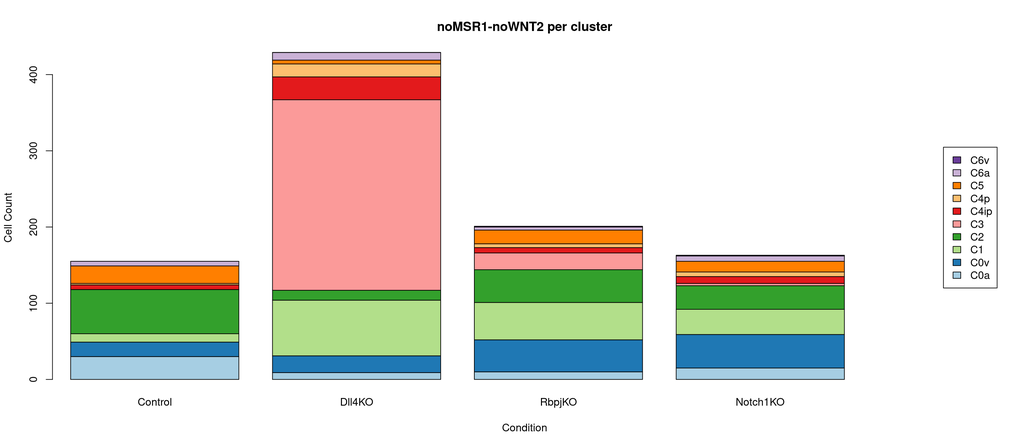

```r
p1 <- barplot(ncell_list_noMSR1_noWNT2, xlim = c(0.3, 5.5), col = my_palette, axisnames = T, ylab = "Cell Count", xlab = "Condition", legend.text = c("C0a", "C0v", "C1", "C2", "C3", "C4ip", "C4p", "C5", "C6a", "C6v"), args.legend = list(x = "right", inset = c(0, 0)), main = "noMSR1-noWNT2 per cluster")
```

```r
ncell_list_MSR1hi_noWNT2 <- matrix(c("Control" = ncell_list_per_cluster_Control[1:10, 2], "Dll4KO" = ncell_list_per_cluster_Dll4KO[1:10, 2], "RbpjKO" =
                                  ncell_list_per_cluster_RbpjKO[1:10, 2], "Notch1KO" = ncell_list_per_cluster_Notch1KO[1:10, 2]), nrow = 10, ncol = 4,
                         dimnames = list(c("C0a", "C0v", "C1", "C2", "C3", "C4ip", "C4p", "C5", "C6a", "C6v"),
                                         c("Control", "Dll4KO", "RbpjKO", "Notch1KO")))
ncell_list_MSR1hi_noWNT2
```

```
##      Control Dll4KO RbpjKO Notch1KO
## C0a      101      0      0        2
## C0v        8      0     11        6
## C1         0      0      2        1
## C2        55      0     21        2
## C3         0      0      0        0
## C4ip       3      0      4        0
## C4p        0      0      1        0
## C5        10      0      5        0
## C6a       26      0      0        1
## C6v        0      0      0        0
```

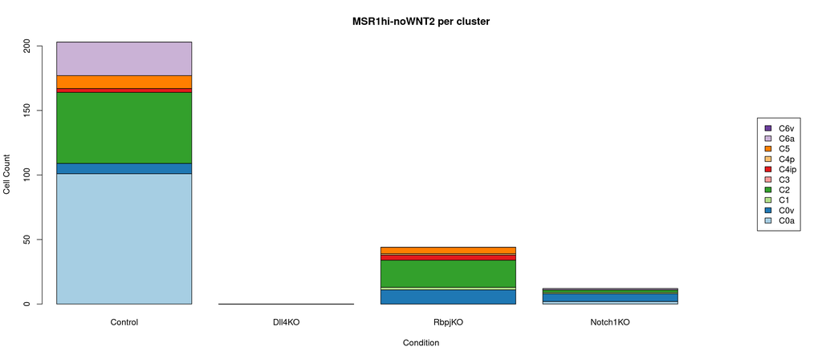

```r
p2 <- barplot(ncell_list_MSR1hi_noWNT2, xlim = c(0.3, 5.5), col = my_palette, axisnames = T, ylab = "Cell Count", xlab = "Condition", legend.text = c("C0a", "C0v", "C1", "C2", "C3", "C4ip", "C4p", "C5", "C6a", "C6v"), args.legend = list(x = "right", inset = c(0, 0)), main = "MSR1hi-noWNT2 per cluster")
```

```r
ncell_list_MSR1lo_noWNT2 <- matrix(c("Control" = ncell_list_per_cluster_Control[1:10, 3], "Dll4KO" = ncell_list_per_cluster_Dll4KO[1:10, 3], "RbpjKO" =
                                  ncell_list_per_cluster_RbpjKO[1:10, 3], "Notch1KO" = ncell_list_per_cluster_Notch1KO[1:10, 3]), nrow = 10, ncol = 4,
                         dimnames = list(c("C0a", "C0v", "C1", "C2", "C3", "C4ip", "C4p", "C5", "C6a", "C6v"),
                                         c("Control", "Dll4KO", "RbpjKO", "Notch1KO")))
ncell_list_MSR1lo_noWNT2
```

```
##      Control Dll4KO RbpjKO Notch1KO
## C0a       75      0      8        8
## C0v       13      2     55       16
## C1         2     23     62       24
## C2        23      0     27        8
## C3         0     50     19        0
## C4ip       2     16     20        4
## C4p        2      8     14        2
## C5         8      1      9        2
## C6a       16      3      0        2
## C6v        0      0      0        0
```

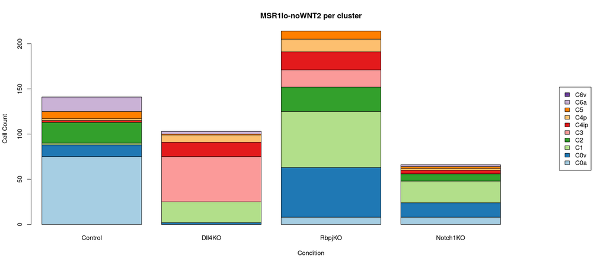

```r
p3 <- barplot(ncell_list_MSR1lo_noWNT2, xlim = c(0.3, 5.5), col = my_palette, axisnames = T, ylab = "Cell Count", xlab = "Condition", legend.text = c("C0a", "C0v", "C1", "C2", "C3", "C4ip", "C4p", "C5", "C6a", "C6v"), args.legend = list(x = "right", inset = c(0, 0)), main = "MSR1lo-noWNT2 per cluster")
```

```r
ncell_list_MSR1hi_WNT2lo <- matrix(c("Control" = ncell_list_per_cluster_Control[1:10, 4], "Dll4KO" = ncell_list_per_cluster_Dll4KO[1:10, 4], "RbpjKO" =
                                  ncell_list_per_cluster_RbpjKO[1:10, 4], "Notch1KO" = ncell_list_per_cluster_Notch1KO[1:10, 4]), nrow = 10, ncol = 4,
                         dimnames = list(c("C0a", "C0v", "C1", "C2", "C3", "C4ip", "C4p", "C5", "C6a", "C6v"),
                                         c("Control", "Dll4KO", "RbpjKO", "Notch1KO")))
ncell_list_MSR1hi_WNT2lo
```

```
##      Control Dll4KO RbpjKO Notch1KO
## C0a       50      0      5        3
## C0v        8      0     31       12
## C1         1      0     13        0
## C2         8      0      4        1
## C3         0      0      0        0
## C4ip       2      0      4        0
## C4p        0      0      1        1
## C5         0      0      1        0
## C6a        1      0      0        0
## C6v        0      0      0        0
```

[figure not shown]

```r
p4 <- barplot(ncell_list_MSR1hi_WNT2lo, xlim = c(0.3, 5.5), col = my_palette, axisnames = T, ylab = "Cell Count", xlab = "Condition", legend.text = c("C0a", "C0v", "C1", "C2", "C3", "C4ip", "C4p", "C5", "C6a", "C6v"), args.legend = list(x = "right", inset = c(0, 0)), main = "MSR1lo-noWNT2 per cluster")
```

```r
ncell_list_MSR1lo_WNT2lo <- matrix(c("Control" = ncell_list_per_cluster_Control[1:10, 5], "Dll4KO" = ncell_list_per_cluster_Dll4KO[1:10, 5], "RbpjKO" =
                                  ncell_list_per_cluster_RbpjKO[1:10, 5], "Notch1KO" = ncell_list_per_cluster_Notch1KO[1:10, 5]), nrow = 10, ncol = 4,
                         dimnames = list(c("C0a", "C0v", "C1", "C2", "C3", "C4ip", "C4p", "C5", "C6a", "C6v"),
                                         c("Control", "Dll4KO", "RbpjKO", "Notch1KO")))
ncell_list_MSR1lo_WNT2lo
```

```
##      Control Dll4KO RbpjKO Notch1KO
## C0a       36      1      5       10
## C0v       21      5    137      101
## C1         4     62     89       53
## C2         4      1     17       12
## C3         0     17      4        0
## C4ip       2     17     37       15
## C4p        1      7     13        9
## C5         0      0      5        0
## C6a        1      2      1        1
## C6v        1      0      0        1
```

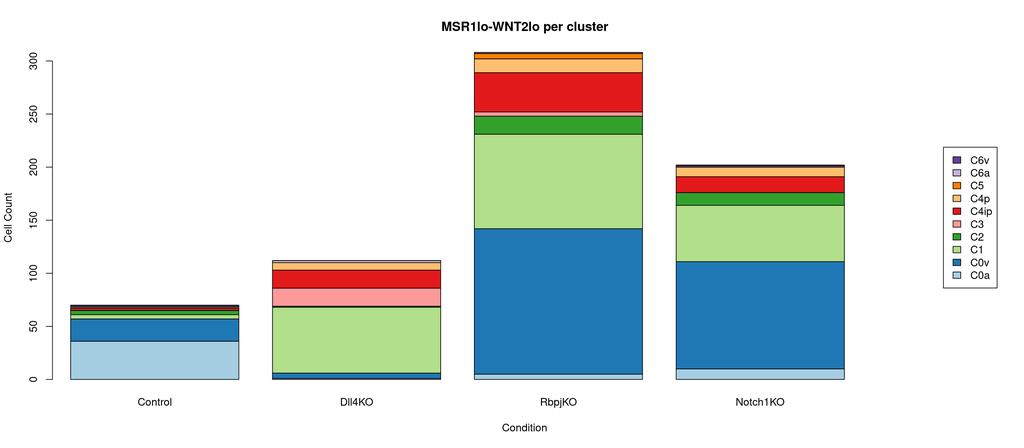

```r
p5 <- barplot(ncell_list_MSR1lo_WNT2lo, xlim = c(0.3, 5.5), col = my_palette, axisnames = T, ylab = "Cell Count", xlab = "Condition", legend.text = c("C0a", "C0v", "C1", "C2", "C3", "C4ip", "C4p", "C5", "C6a", "C6v"), args.legend = list(x = "right", inset = c(0, 0)), main = "MSR1lo-WNT2lo per cluster")
```

```r
ncell_list_MSR1hi_WNT2hi <- matrix(c("Control" = ncell_list_per_cluster_Control[1:10, 6], "Dll4KO" = ncell_list_per_cluster_Dll4KO[1:10, 6], "RbpjKO" =
                                  ncell_list_per_cluster_RbpjKO[1:10, 6], "Notch1KO" = ncell_list_per_cluster_Notch1KO[1:10, 6]), nrow = 10, ncol = 4,
                         dimnames = list(c("C0a", "C0v", "C1", "C2", "C3", "C4ip", "C4p", "C5", "C6a", "C6v"),
                                         c("Control", "Dll4KO", "RbpjKO", "Notch1KO")))
ncell_list_MSR1hi_WNT2hi
```

```
##      Control Dll4KO RbpjKO Notch1KO
## C0a        1      0      0        1
## C0v        0      0      0        2
## C1         0      0      0        0
## C2         2      0      2        4
## C3         0      0      0        0
## C4ip       0      0      0        0
## C4p        0      0      0        0
## C5         0      0      0        0
## C6a        0      0      0        0
## C6v        0      0      0        0
```

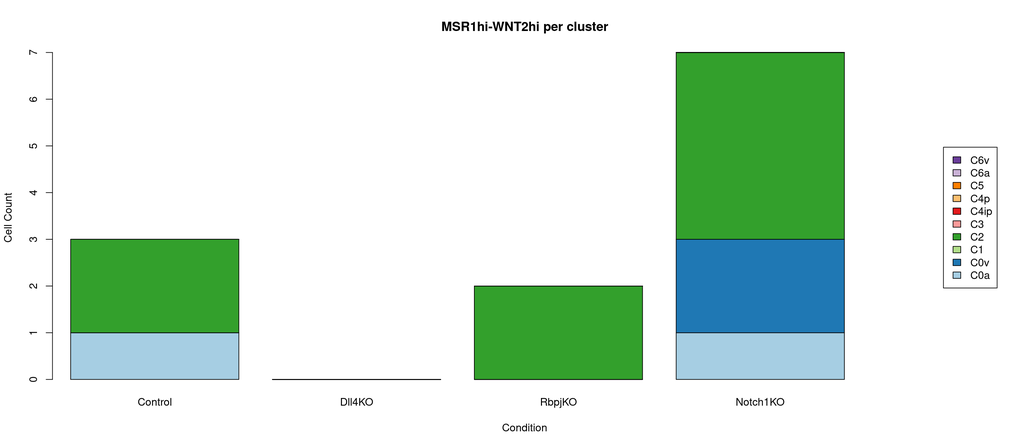

```r
p6 <- barplot(ncell_list_MSR1hi_WNT2hi, xlim = c(0.3, 5.5), col = my_palette, axisnames = T, ylab = "Cell Count", xlab = "Condition", legend.text = c("C0a", "C0v", "C1", "C2", "C3", "C4ip", "C4p", "C5", "C6a", "C6v"), args.legend = list(x = "right", inset = c(0, 0)), main = "MSR1hi-WNT2hi per cluster")
```

```r
ncell_list_MSR1lo_WNT2hi <- matrix(c("Control" = ncell_list_per_cluster_Control[1:10, 7], "Dll4KO" = ncell_list_per_cluster_Dll4KO[1:10, 7], "RbpjKO" =
                                  ncell_list_per_cluster_RbpjKO[1:10, 7], "Notch1KO" = ncell_list_per_cluster_Notch1KO[1:10, 7]), nrow = 10, ncol = 4,
                         dimnames = list(c("C0a", "C0v", "C1", "C2", "C3", "C4ip", "C4p", "C5", "C6a", "C6v"),
                                         c("Control", "Dll4KO", "RbpjKO", "Notch1KO")))
ncell_list_MSR1lo_WNT2hi
```

```
##      Control Dll4KO RbpjKO Notch1KO
## C0a        2      0      1        1
## C0v        2      0     22       32
## C1         0      4      2        8
## C2         1      0      3        3
## C3         0      0      0        0
## C4ip       0      0      1        4
## C4p        0      0      0        0
## C5         0      0      3        0
## C6a        0      0      0        0
## C6v        1      0      0        3
```

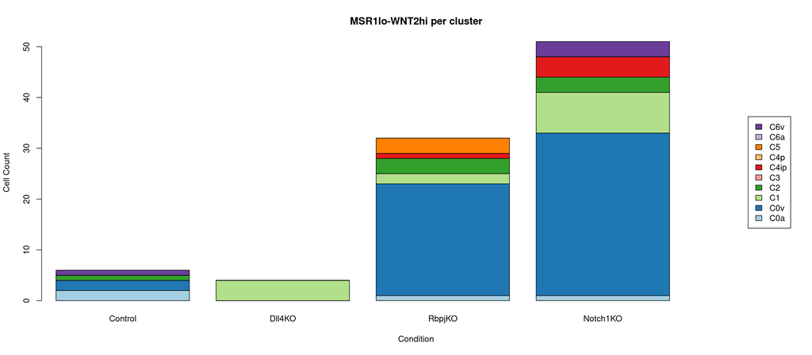

```r
p7 <- barplot(ncell_list_MSR1lo_WNT2hi, xlim = c(0.3, 5.5), col = my_palette, axisnames = T, ylab = "Cell Count", xlab = "Condition", legend.text = c("C0a", "C0v", "C1", "C2", "C3", "C4ip", "C4p", "C5", "C6a", "C6v"), args.legend = list(x = "right", inset = c(0, 0)), main = "MSR1lo-WNT2hi per cluster")
```

```r
ncell_list_noMSR1_WNT2lo <- matrix(c("Control" = ncell_list_per_cluster_Control[1:10, 8], "Dll4KO" = ncell_list_per_cluster_Dll4KO[1:10, 8], "RbpjKO" =
                                  ncell_list_per_cluster_RbpjKO[1:10, 8], "Notch1KO" = ncell_list_per_cluster_Notch1KO[1:10, 8]), nrow = 10, ncol = 4,
                         dimnames = list(c("C0a", "C0v", "C1", "C2", "C3", "C4ip", "C4p", "C5", "C6a", "C6v"),
                                         c("Control", "Dll4KO", "RbpjKO", "Notch1KO")))
ncell_list_noMSR1_WNT2lo
```

```
##      Control Dll4KO RbpjKO Notch1KO
## C0a       17      2      5        5
## C0v       70     24     57      137
## C1        11    123     43       77
## C2        26      5     16       24
## C3         0     31      4        2
## C4ip       8     27     14       17
## C4p        2     10      9       11
## C5        14      2      7        8
## C6a        1      9      2        1
## C6v       16      5      3        4
```

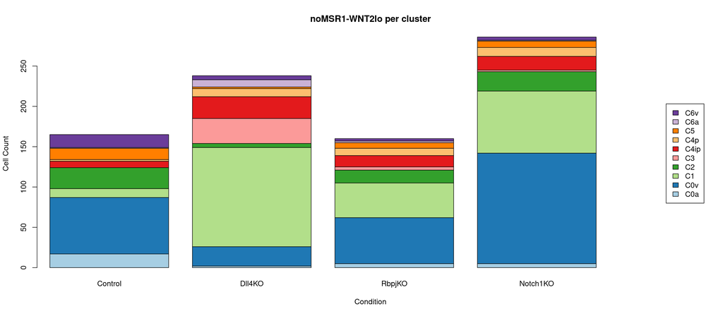

```r
p8 <- barplot(ncell_list_noMSR1_WNT2lo, xlim = c(0.3, 5.5), col = my_palette, axisnames = T, ylab = "Cell Count", xlab = "Condition", legend.text = c("C0a", "C0v", "C1", "C2", "C3", "C4ip", "C4p", "C5", "C6a", "C6v"), args.legend = list(x = "right", inset = c(0, 0)), main = "noMSR1-WNT2lo per cluster")
```

```r
ncell_list_noMSR1_WNT2hi <- matrix(c("Control" = ncell_list_per_cluster_Control[1:10, 9], "Dll4KO" = ncell_list_per_cluster_Dll4KO[1:10, 9], "RbpjKO" =
                                  ncell_list_per_cluster_RbpjKO[1:10, 9], "Notch1KO" = ncell_list_per_cluster_Notch1KO[1:10, 9]), nrow = 10, ncol = 4,
                         dimnames = list(c("C0a", "C0v", "C1", "C2", "C3", "C4ip", "C4p", "C5", "C6a", "C6v"),
                                         c("Control", "Dll4KO", "RbpjKO", "Notch1KO")))
ncell_list_noMSR1_WNT2hi
```

```
##      Control Dll4KO RbpjKO Notch1KO
## C0a       21      2      6        8
## C0v      115     33     74      228
## C1        11    145     45       84
## C2        39      5     24       39
## C3         0     32      4        2
## C4ip       8     28     14       25
## C4p        2     11      9       12
## C5        18      2     11       16
## C6a        1     10      2        1
## C6v       41      7     11       20
```

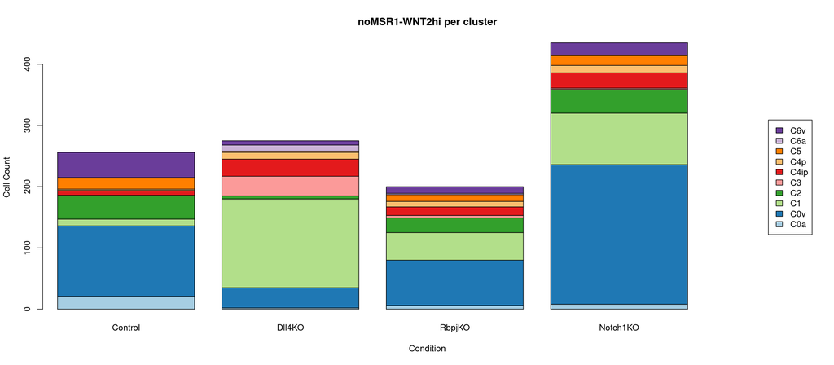

```r
p9 <- barplot(ncell_list_noMSR1_WNT2hi, xlim = c(0.3, 5.5), col = my_palette, axisnames = T, ylab = "Cell Count", xlab = "Condition", legend.text = c("C0a", "C0v", "C1", "C2", "C3", "C4ip", "C4p", "C5", "C6a", "C6v"), args.legend = list(x = "right", inset = c(0, 0)), main = "noMSR1-WNT2hi per cluster")
```

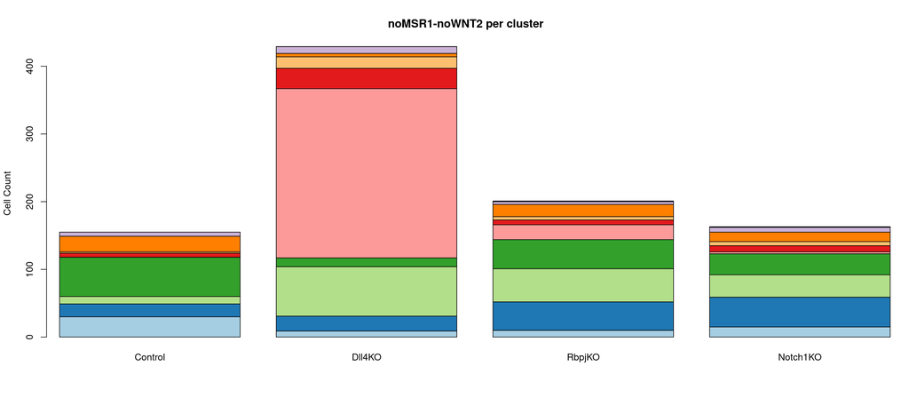

```r
p1 <- barplot(ncell_list_noMSR1_noWNT2, xlim = c(0.3, 4.6), col = my_palette, ylab = "Cell Count", main = "noMSR1-noWNT2 per cluster")
```

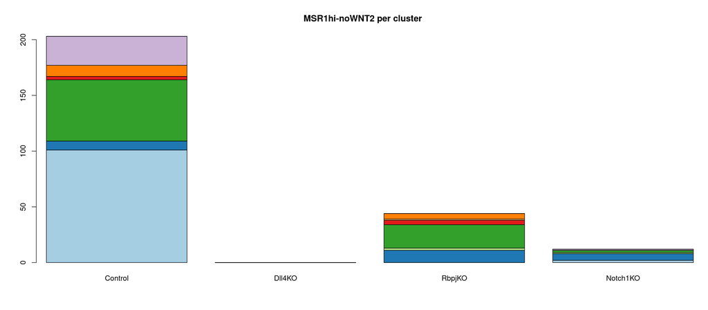

```r
p2 <- barplot(ncell_list_MSR1hi_noWNT2, xlim = c(0.3, 4.6), col = my_palette, main = "MSR1hi-noWNT2 per cluster")
```

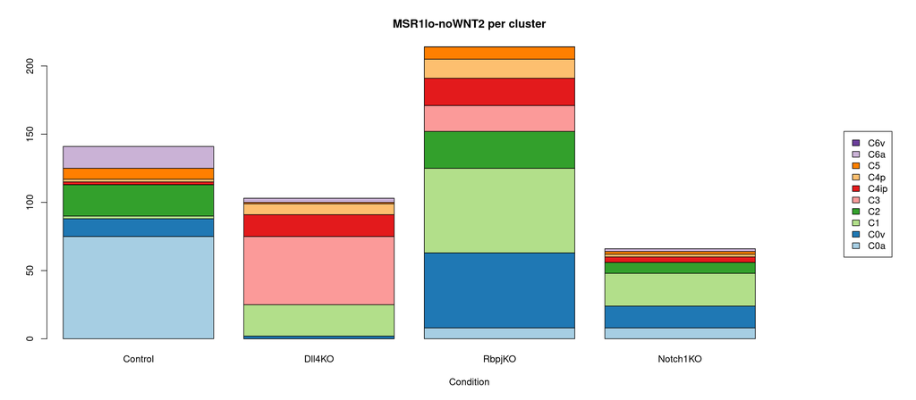

```r
p3 <- barplot(ncell_list_MSR1lo_noWNT2, xlim = c(0.3, 5.5), col = my_palette, axisnames = T, xlab = "Condition", legend.text = c("C0a", "C0v", "C1", "C2", "C3", "C4ip", "C4p", "C5", "C6a", "C6v"), args.legend = list(x = "right", inset = c(0, 0)), main = "MSR1lo-noWNT2 per cluster")
```

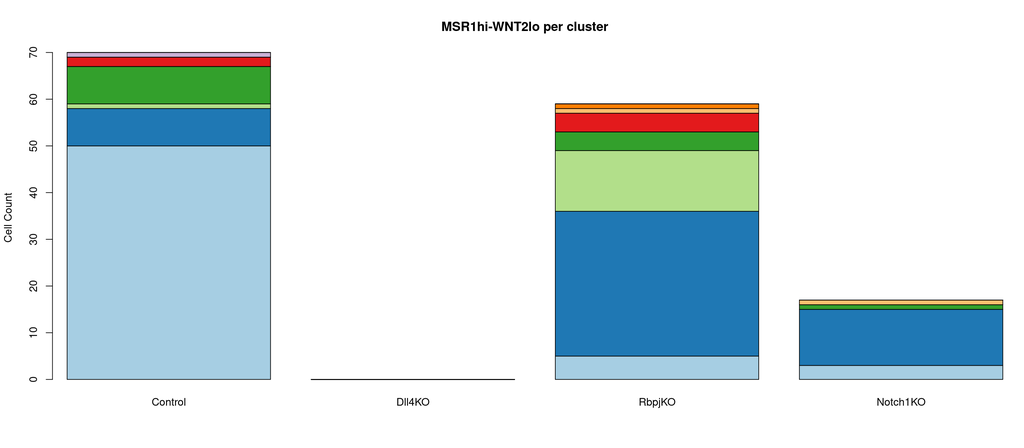

```r
p4 <- barplot(ncell_list_MSR1hi_WNT2lo, xlim = c(0.3, 4.6), col = my_palette, ylab = "Cell Count", main = "MSR1hi-WNT2lo per cluster")
```

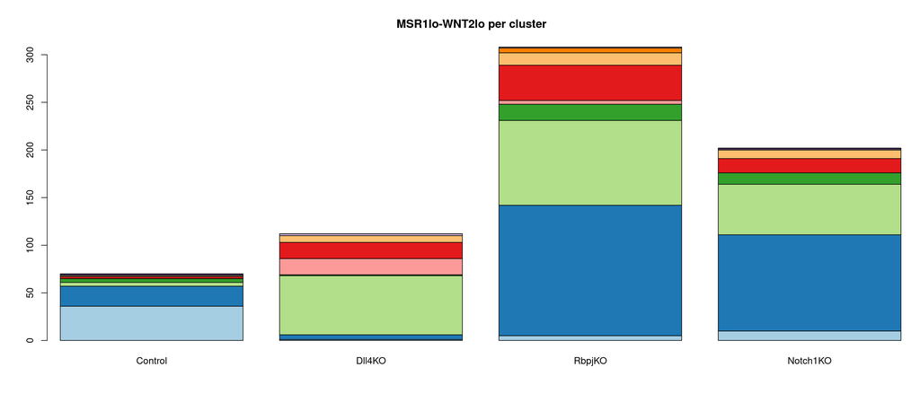

```r
p5 <- barplot(ncell_list_MSR1lo_WNT2lo, xlim = c(0.3, 4.6), col = my_palette, main = "MSR1lo-WNT2lo per cluster")
```

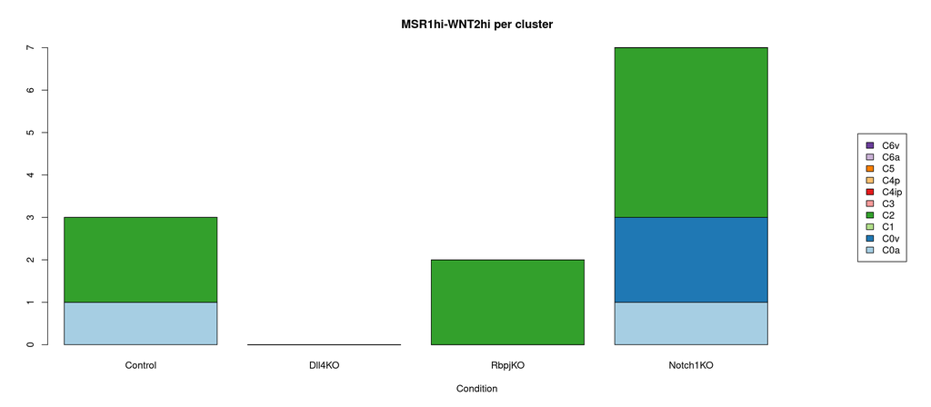

```r
p6 <- barplot(ncell_list_MSR1hi_WNT2hi, xlim = c(0.3, 5.5), col = my_palette, axisnames = T, xlab = "Condition", legend.text = c("C0a", "C0v", "C1", "C2", "C3", "C4ip", "C4p", "C5", "C6a", "C6v"), args.legend = list(x = "right", inset = c(0, 0)), main = "MSR1hi-WNT2hi per cluster")
```

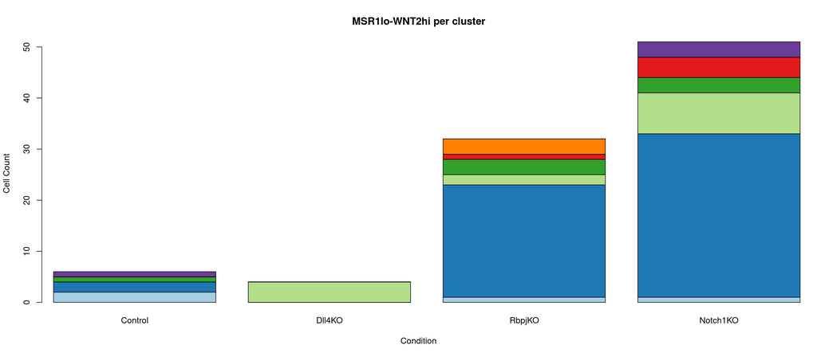

```r
p7 <- barplot(ncell_list_MSR1lo_WNT2hi, xlim = c(0.3, 4.6), col = my_palette, ylab = "Cell Count", xlab = "Condition", main = "MSR1lo-WNT2hi per cluster")
```

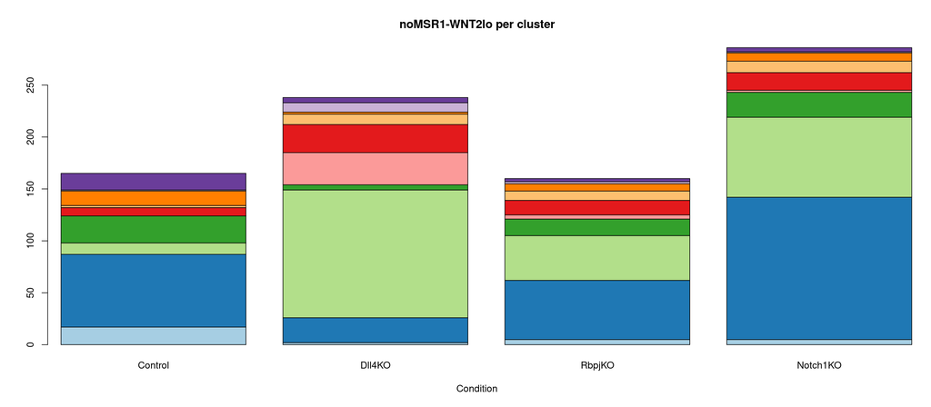

```r
p8 <- barplot(ncell_list_noMSR1_WNT2lo, xlim = c(0.3, 4.6), col = my_palette, xlab = "Condition", main = "noMSR1-WNT2lo per cluster")
```

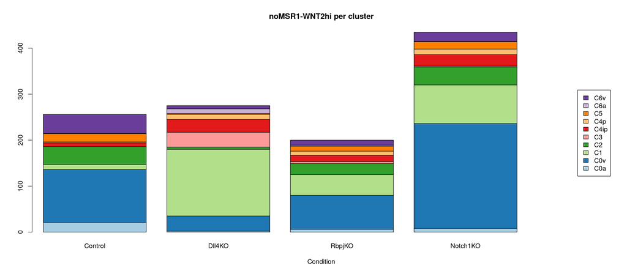

```r
p9 <- barplot(ncell_list_noMSR1_WNT2hi, xlim = c(0.3, 5.5), col = my_palette, axisnames = T, xlab = "Condition", legend.text = c("C0a", "C0v", "C1", "C2", "C3", "C4ip", "C4p", "C5", "C6a", "C6v"), args.legend = list(x = "right", inset = c(0, 0)), main = "noMSR1-WNT2hi per cluster")
```

```r
cells_per_cluster_per_condition <- matrix(c(colSums(ncell_list_noMSR1_noWNT2),colSums(ncell_list_MSR1hi_noWNT2),colSums(ncell_list_MSR1lo_noWNT2),colSums(ncell_list_MSR1hi_WNT2lo),colSums(ncell_list_MSR1lo_WNT2lo),colSums(ncell_list_MSR1hi_WNT2hi),colSums(ncell_list_MSR1lo_WNT2hi),colSums(ncell_list_noMSR1_WNT2lo), colSums(ncell_list_noMSR1_WNT2hi)))

cells_per_cluster_per_condition
```

```
##       [,1]
##  [1,]  155
##  [2,]  429
##  [3,]  201
##  [4,]  163
##  [5,]  203
##  [6,]    0
##  [7,]   44
##  [8,]   12
##  [9,]  141
## [10,]  103
## [11,]  214
## [12,]   66
## [13,]   70
## [14,]    0
```

[output cut: 22 more lines]

```r
ncell_list_noMSR1_noWNT2_norm <- matrix(c(100*ncell_list_noMSR1_noWNT2[1:10]/cells_per_cluster_per_condition[1],
                                          100*ncell_list_noMSR1_noWNT2[11:20]/cells_per_cluster_per_condition[2],
                                          100*ncell_list_noMSR1_noWNT2[21:30]/cells_per_cluster_per_condition[3],
                                          100*ncell_list_noMSR1_noWNT2[31:40]/cells_per_cluster_per_condition[4]), ncol = 4,
                                        dimnames = list(c("C0a", "C0v", "C1", "C2", "C3", "C4ip", "C4p", "C5", "C6a", "C6v"),
                                                        c("Control=155", "Dll4KO=429", "RbpjKO=201", "Notch1KO=163")))

ncell_list_noMSR1_noWNT2_norm
```

```
##      Control=155 Dll4KO=429 RbpjKO=201 Notch1KO=163
## C0a    19.354839   2.097902  4.9751244    9.2024540
## C0v    12.258065   5.128205 20.8955224   26.9938650
## C1      7.096774  17.016317 24.3781095   20.2453988
## C2     37.419355   3.030303 21.3930348   19.0184049
## C3      0.000000  58.275058 10.9452736    1.8404908
## C4ip    3.870968   6.993007  3.4825871    5.5214724
## C4p     1.290323   3.962704  2.4875622    3.6809816
## C5     14.838710   1.165501  8.9552239    8.5889571
## C6a     3.870968   2.331002  1.9900498    4.2944785
## C6v     0.000000   0.000000  0.4975124    0.6134969
```

```r
ncell_list_MSR1hi_noWNT2_norm <- matrix(c(100*ncell_list_MSR1hi_noWNT2[1:10]/cells_per_cluster_per_condition[5],
                                          100*ncell_list_MSR1hi_noWNT2[11:20]/cells_per_cluster_per_condition[6],
                                          100*ncell_list_MSR1hi_noWNT2[21:30]/cells_per_cluster_per_condition[7],
                                          100*ncell_list_MSR1hi_noWNT2[31:40]/cells_per_cluster_per_condition[8]),
                                        ncol = 4,
                                        dimnames = list(c("C0a", "C0v", "C1", "C2", "C3", "C4ip", "C4p", "C5", "C6a", "C6v"),
                                                        c("Control=203", "Dll4KO=0", "RbpjKO=44", "Notch1KO=12")))

ncell_list_MSR1hi_noWNT2_norm
```

```
##      Control=203 Dll4KO=0 RbpjKO=44 Notch1KO=12
## C0a    49.753695      NaN  0.000000   16.666667
## C0v     3.940887      NaN 25.000000   50.000000
## C1      0.000000      NaN  4.545455    8.333333
## C2     27.093596      NaN 47.727273   16.666667
## C3      0.000000      NaN  0.000000    0.000000
## C4ip    1.477833      NaN  9.090909    0.000000
## C4p     0.000000      NaN  2.272727    0.000000
## C5      4.926108      NaN 11.363636    0.000000
## C6a    12.807882      NaN  0.000000    8.333333
## C6v     0.000000      NaN  0.000000    0.000000
```